# Pre-processing of metadata and expression matrices

Urwah Nawaz

2023-09-20

# Introduction

This R markdown document contains code to pre-process RNA-seq files for BITHub. Both expression matrices and metadata were retrieved as described in Table 1 in the GitHub Repository.

In order to re-run the scripts, please change the location of input files. All directories are defined in `config/paths-example.yaml`. For each dataset, a pre-defined annotation file exists in the `data/annotations` folder. These files contains the original metadata name, and the BITHub column name for each dataset.

A copy of each processed metadata will also be saved in ‘output/metadata/’.

## Selection of metadata variables

Each metadata column was categorized into one of the following four categories:

- Phenotype attributes, describing observable characteristics relating to samples such as DonorID, Diagnosis, Sex and Age.
- Sample characteristics: referring to sample specific metrics such as site of sampling.
- Sequencing metrics: covering quality control (QC) metrics of a given RNA-seq sample, including QC output of bioinformatics protocol of a given sample.
- Cell type: capturing information on cell-types or cell specific metrics related to the single-nucleus RNA-seq or cell-type deconvolution for bulk RNA-seq datasets.

Metadata were filtered prior to inclusion in BITHub to redunce redundancy and improve inerpretability.

Filtering rules:

- Drop variables with a single value across all samples
- Drop variables with mostly missing values of `NA/Unknown`
- Drop categorial variables with > 50 categories (e.g DonorID)
- For sequencing metrics, drop variables that are highly correlated with another metric within the same dataset and keep one representative metric

Metadata were filtered prior to inclusion in BITHub to reduce redundancy and improve interpretability.

Filtering excluded:

- Variables with a single value across samples
- Variables with predominantly missing values
- Categorical variables with more than 50 levels.

Sequencing metrics that were highly correlated within a dataset were flagged to identify redundancy, and typically one representative metric was retained. Exceptions were made after manual review when keeping both metrics was useful and informative.

```r
library(recount3)
library(magrittr)
library(tibble)
library(reshape2)
library(SummarizedExperiment)
library(corrplot)
library(dplyr)
library(ggvenn)
library(pander)
library(gridExtra)
library(variancePartition)
library(DT)
library(EnsDb.Hsapiens.v86)
library(AnnotationHub)
library(stargazer)
library(ggfortify)
library(patchwork)
library(foreach)
library(glue)
library(cowplot)
library(broom)
library(glmpca)
library(DT)
library(naniar)
library(Seurat)
source(here::here("code/functions.R"))
source(here::here("code/def_stages.R"))
source(here::here("code/def_death.R"))
source(here::here("code/def_regions.R"))

paths <- yaml::read_yaml(here::here("config/paths-example.yaml"))
```

```r
strc_acr <- map_df(structure_acronym, ~as.data.frame(.x), .id="id") %>%
  set_colnames("Structure Acronym")
colnames(strc_acr)[2] = c("Structure")

rgns = map_df(regions, ~as.data.frame(.x), .id="id") %>%
  set_colnames("Regions")
colnames(rgns)[2] = c("Structure Acronym")


rgns_ftl = map_df(regions_fetal, ~as.data.frame(.x), .id="id") %>%
  set_colnames("Regions")
colnames(rgns_ftl)[2] = c("Structure Acronym")

order_vec <- c("Phenotype",
               "Sample characteristics",
               "Cell Type",
               "Sequencing metrics")
```

# Bulk RNA-seq data

## BrainSeq

The BrainSeq data used for BITHub is obtained from BrainSeq Phase 2, which comprises RiboZero bulk RNA-seq data from the dorsolateral prefrontal cortex (DLPFC), and hippocampus (HIP). This cohort includes neurotypical individuals spanning from prenatal stages to ageing, as well as adult patients diagnosed with schizophrenia.

The [gene expression matrices and the corresponding sample level metadata](https://s3.us-east-2.amazonaws.com/libd-brainseq2/rse_gene_unfiltered.Rdata) were downloaded from the BrainSeq consortium website. The release also includes pre-computed [cell type deconvolution estimates](https://s3.us-east-2.amazonaws.com/libd-brainseq2/methprop_pd.Rdata) which were generated as a part of the BrainSeq Phase 2 processing pipeline.

### Metadata pre-processing

```r
bseq.annot = read.csv(here::here("data/annotations/BrainSeq-metadata-annot.csv"),
                      header = TRUE,
                      check.names=FALSE)
load(file.path(paths$bulk$raw$brainseq, "rse_gene_unfiltered.Rdata"), envir = .GlobalEnv)
load(file.path(paths$bulk$raw$brainseq,"methprop_pd.Rdata"), envir = .GlobalEnv)
```

```r
x = rse_gene@colData %>%
  as.data.frame() %>%
  t() %>% as.data.frame()
replicated <- colnames(x)[grep(",", x["SAMPLE_ID",])]
y <- as.list(x)
y[replicated] <- lapply(y[replicated], function(z) {
  # which variables to merge
  to.weight <- which(sapply(z, length) > 1 & sapply(z, class) %in% c("numeric", "integer"))
  # weighting of the merge
  weighting <- z$numReads # total reads
  weighting <- weighting / sum(weighting) # rather than a straight average, it's based on the number of reads

  # apply weighting
  z[to.weight] <- lapply(z[to.weight], function(zz) {
    if (length(weighting) == length(zz)) {
      sum(weighting * zz)
      } else {
          NaN
        }

      })

      # quickly fix character variables
      char <- which(sapply(z, length) > 1 & sapply(z, class) == "character")
      z[char] <- lapply(z[char], function(zz) {
        paste(zz, collapse = " & ")
      })

      return(z)
    })

w <- lapply(y, as.data.frame)
w <- do.call("rbind", w)
comp <- as.data.frame(pd)
comp <- comp[,57:64]
m <- match(rownames(comp), rownames(w)) # they are
md<- cbind(w, comp[m,])

md = rename_from_annot(md, bseq.annot)


# Adding features
md %<>%
  rownames_to_column("SampleID") %>%
  mutate(Period = ifelse(.$`Age (Numeric)` > 0, "Postnatal", "Prenatal"),
                   `Structure Acronym` = gsub("HIPPO", "HIP", .$`Structure Acronym`),
                   Diagnosis = gsub("Schizo", "Schizophrenia", .$Diagnosis)) %>%
      mutate(Regions = add_feature(.$`Structure Acronym`, regions)) %>%
      mutate(Age_rounded = as.character(sapply(na.omit(.$`Age (Numeric)`), num_to_round))) %>% as.data.frame() %>%
      mutate(`Age Interval` = as.character(add_feature(.$Age_rounded, age_intervals))) %>%
      dplyr::select(-Age_rounded) %>%
      dplyr::select("SampleID", everything()) %>%
      as.data.frame()
```

After harmonization of metadata, a series of exploratory analyses, including correlation analysis was performed to remove redundant or non-informative metadata.

For categorical metadata, a table is shown below which total number of unique values in each category.

```r
cat_tbl <- cat_summary(md, max_show = 50)


cat_tbl %>% as.data.frame() %>% DT::datatable(caption= "Summary of all categorial metadata in BrainSeq")
```

|  | column | n_unique | values |
| --- | --- | --- | --- |
| 1 | SampleID | 900 | &gt; 50 |
| 2 | SAMPLE_ID | 900 | &gt; 50 |
| 3 | FQCbasicStats | 1 | PASS |
| 4 | perBaseQual | 11 | FAIL, FAIL &amp; FAIL/PASS, FAIL &amp; PASS, FAIL/PASS, FAIL/PASS &amp; PASS, PASS, PASS &amp; FAIL, PASS &amp; FAIL/PASS, PASS/FAIL, PASS/FAIL &amp; FAIL/PASS, PASS/FAIL &amp; PASS |
| 5 | perTileQual | 33 | FAIL/PASS, FAIL/WARN, FAIL/WARN &amp; FAIL/PASS, FAIL/WARN &amp; FAIL/PASS &amp; PASS, PASS, PASS &amp; FAIL/PASS, PASS &amp; FAIL/PASS &amp; WARN/PASS, PASS &amp; FAIL/WARN &amp; WARN/PASS, PASS &amp… |
| 6 | perSeqQual | 1 | PASS |
| 7 | perBaseContent | 6 | FAIL, FAIL &amp; FAIL/WARN, FAIL/WARN, FAIL/WARN &amp; FAIL, WARN, WARN/FAIL |
| 8 | GCcontent | 13 | FAIL, FAIL/PASS, FAIL/WARN, PASS, PASS/WARN, PASS/WARN &amp; WARN, WARN, WARN &amp; FAIL/WARN &amp; FAIL/PASS, WARN &amp; PASS/WARN, WARN &amp; WARN/FAIL, WARN/FAIL, WARN/FAIL &amp; WARN, WARN/PASS |
| 9 | Ncontent | 5 | FAIL/PASS, PASS, PASS/WARN, WARN, WARN/PASS |
| 10 | SeqLengthDist | 1 | PASS |

[output cut: 15 more lines]

For sequencing metrics, a correlation analysis was performed using the `corrplot` R package.

```r
seq_cols <- get_seq_metrics_cols(bseq.annot)
seq_cols <- intersect(seq_cols, colnames(md))
```

```r
res <- select_seq_metrics(
  md = md,
  seq_cols = seq_cols,
  corr_thresh = 0.95,
  missing_thresh = 0.5,
  min_unique = 2,
  prefer = "less_missing"
)

res$summary %>% DT::datatable(caption="Summary and correlation of all seqeuncing metrics metadata in BrainSeq")
```

|  | Metric | class | n_total | n_missing | frac_missing | n_unique_nonmissing | keep_final | drop_reason_final |
| --- | --- | --- | --- | --- | --- | --- | --- | --- |
| 1 | Total N Reads | numeric | 900 | 0 | 0 | 900 | True |  |
| 2 | Number of Reads Unmapped | numeric | 900 | 0 | 0 | 900 | True |  |
| 3 | Reads Mapped | numeric | 900 | 0 | 0 | 900 | True |  |
| 4 | Reads Mapped to Mitochondrial Genes | numeric | 900 | 0 | 0 | 900 | True |  |
| 5 | Mito Ratio | numeric | 900 | 0 | 0 | 900 | True |  |
| 6 | Total Assigned Gene | numeric | 900 | 0 | 0 | 900 | True |  |
| 7 | rRNA ratio | numeric | 900 | 0 | 0 | 900 | True |  |
| 8 | phredGT35_R1 | numeric | 900 | 0 | 0 | 900 | True |  |
| 9 | phredGT35_R2 | numeric | 900 | 0 | 0 | 900 | True |  |
| 10 | Adapter88_R2 | numeric | 900 | 0 | 0 | 900 | True |  |

[output cut: 36 more lines]

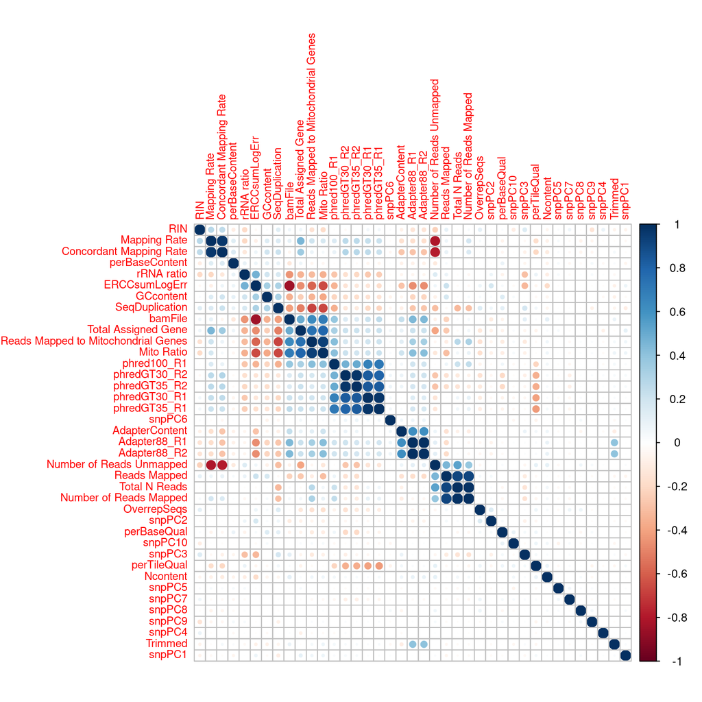

Correlation plot showing correlation of sequencing metrics in BrainSeq

```r
md.clean = md %>%
  dplyr::select(contains(seq_cols))
md.clean = md.clean %>% select_if(~ !any(is.na(.)))
md.clean = md.clean[vapply(md.clean, function(x) length(unique(x)) > 1, logical(1L))]

M = cor(data.matrix(md.clean), use = "complete.obs")
corrplot(M, order='hclust',
         method = "circle",
         number.cex = .50,
         tl.cex=0.75)
```

Based on the above filtering criteria, followed by manual inspection, categorial metadata which have >50 unique or non-informative values were dropped. Additionally highly correlating sequencing metrics were also dropped. Additionally, FastQC metrics and SNP-based principal components were also removed.

```r
bseq.order = bseq.annot %>%
  dplyr::mutate(`Include (Yes/No) - Interest` = ifelse(BITColumnName == "Reads Mapped to Mitochondrial Genes", "No", `Include (Yes/No) - Interest`)) %>%
  dplyr::filter(`Include (Yes/No) - Interest` == "Yes") %>%
  arrange(factor(Type, levels = order_vec)) %>%
  arrange(factor(BITColumnName, levels = c("SampleID",
                                          "Age Interval",
                                          "Age (Numeric)",
                                          "Period",
                                          "DonorID",
                                          "Sex",
                                          "Ethnicity",
                                          "Diagnosis",
                                          "Structure Acronym",
                                          "Regions",
                                          "Proportion of Neurons (MultiBrain)",
                                          "Proportion of Astrocytes (MultiBrain)",
                                          "Proportion of Microglia (MultiBrain)",
                                          "Proportion of Oligodendrocytes (MultiBrain)",
                                          "Proportion of Endothelia (MultiBrain)"
                                          )))
```

```r
md %>%
  dplyr::select(contains(bseq.order$BITColumnName)) %>%
  DT::datatable(caption = "BrainSeq metadata after harmonizing column names, ages and structure acronyms, and filtering for redundancy.")
```

|  | SampleID | Age Interval | Age (Numeric) | Period | DonorID | Sex | Ethnicity | Diagnosis | Structure Acronym | Regions | Dev Replicating (BrainSeq) | Dev Quiescent (BrainSeq) | Adult OPC (BrainSeq) | Adult Neurons (BrainSeq) | Adult Astrocytes (BrainSeq) | Adult Oligo (BrainSeq) | Adult Microglia (BrainSeq) | Adult Endothelial (BrainSeq) | Trimmed | Total N Reads | Number of Reads Unmapped | Mapping Rate | Concordant Mapping Rate | Mito Ratio | Total Assigned Gene | rRNA ratio | RIN |
| --- | --- | --- | --- | --- | --- | --- | --- | --- | --- | --- | --- | --- | --- | --- | --- | --- | --- | --- | --- | --- | --- | --- | --- | --- | --- | --- | --- |
| 1 | R10424 | 60-69yrs | 64.08 | Postnatal | Br5168 | M | CAUC | Control | DLPFC | Cortex | -3.662055609901632e-18 | 0.008952878720087053 | -7.029383544452723e-18 | 0.5240865033093248 | 0.2919357712482398 | 0.1107059466985201 | 0 | 0.0643189000238282 | False | 137207346 | 12189085 | 0.9112 | 0.8586 | 0.0173585169619773 | 0.360011691217133 | 5.26367757990158e-05 | 6.7 |
| 2 | R12195 | 60-69yrs | 62.61 | Postnatal | Br5073 | M | AA | Schizophrenia | DLPFC | Cortex | -2.198064127833998e-18 | 2.214927228102636e-18 | -4.093759906300629e-18 | 0.4649877169412642 | 0.235789511472253 | 0.2352521853405549 | 0.01507305258662427 | 0.04889753365930365 | False | 186256540 | 13158337 | 0.9294 | 0.8862 | 0.0160281634178264 | 0.40055783013167 | 7.92850345490864e-05 | 8.4 |
| 3 | R12198 | 30-39yrs | 29.98 | Postnatal | Br5217 | M | CAUC | Schizophrenia | DLPFC | Cortex | -1.337003501638075e-18 | 0 | -1.397656639164967e-17 | 0.4689259016885745 | 0.241140800215049 | 0.1780111503763019 | 0.04603861158467166 | 0.06588353613540308 | False | 211587890 | 20912721 | 0.9012 | 0.8541 | 0.0238794782690131 | 0.43847430831918 | 8.75739534075908e-05 | 8.5 |
| 4 | R12199 | 60-69yrs | 65.26 | Postnatal | Br5234 | M | CAUC | Schizophrenia | DLPFC | Cortex | -4.373364559702109e-18 | -1.471138162517117e-19 | -1.286919859359306e-17 | 0.4699464154922284 | 0.2245765819295412 | 0.2428530700417183 | 0 | 0.06262393253651208 | False | 127053710 | 8551666 | 0.9327 | 0.8868 | 0.0153648406120122 | 0.438864477561918 | 6.99381234438195e-05 | 8.8 |
| 5 | R12200 | 30-39yrs | 32.35 | Postnatal | Br5372 | M | AA | Schizophrenia | DLPFC | Cortex | -6.84131420271387e-18 | 0 | -1.60104065846161e-17 | 0.4015780908963167 | 0.2710039044925733 | 0.2853919892474157 | 2.691284248848079e-18 | 0.04202601536369434 | False | 80463970 | 7280550 | 0.9095 | 0.8596 | 0.0108043974658389 | 0.362790704785768 | 8.24223407792787e-05 | 7 |
| 6 | R12258 | 60-69yrs | 69.07 | Postnatal | Br5005 | F | CAUC | Control | DLPFC | Cortex | -1.666048782312156e-18 | -4.307272355385022e-18 | -7.970008473049607e-18 | 0.4716431150651796 | 0.1527496462014744 | 0.2524983873172413 | 0.04942371932285957 | 0.07368513209324526 | False | 71290209.1393023 | 6273685.455062458 | 0.9119325357221508 | 0.8736660285777207 | 0.02457307743292104 | 0.4377928488921808 | 5.183021583141238e-05 | 8.6 |
| 7 | R12259 | 40-49yrs | 48.1 | Postnatal | Br5024 | M | CAUC | Control | DLPFC | Cortex | -6.785793613280324e-18 | 0 | -1.007810092646109e-19 | 0.445884226423554 | 0.1798756078134855 | 0.1526935550821413 | 1.741898140050345e-17 | 0.2215466106808192 | False | 178866358 | 26183453 | 0.8536 | 0.8121 | 0.0359170706502963 | 0.335781979662793 | 0.000116593819900356 | 5.4 |
| 8 | R12260 | 50-59yrs | 50.28 | Postnatal | Br5053 | M | AA | Control | DLPFC | Cortex | -4.015897140816353e-18 | 0 | -8.265238650268344e-18 | 0.4740200211440881 | 0.2574830052538907 | 0.2106573045982245 | 1.461588627864902e-18 | 0.05783966900379663 | False | 297075558 | 28534390 | 0.9039 | 0.8601 | 0.0181815475995765 | 0.4014590592883 | 5.36677652986705e-05 | 7.3 |
| 9 | R12263 | 40-49yrs | 47.01 | Postnatal | Br5146 | F | AA | Control | DLPFC | Cortex | -1.437748315390744e-18 | 0 | 1.81926417382824e-18 | 0.4441321132907784 | 0.1731662662135037 | 0.3236774260233384 | 0.02209874635600469 | 0.03692544811637481 | False | 200226466 | 17289783 | 0.9136 | 0.8681 | 0.0238361334962777 | 0.41877915560943 | 4.9170903198874e-05 | 8.1 |
| 10 | R12264 | 40-49yrs | 49.26 | Postnatal | Br5154 | M | CAUC | Control | DLPFC | Cortex | -1.901211987568691e-18 | 0 | -3.896422500458264e-18 | 0.4839040879943835 | 0.2382168978535148 | 0.1820555548719761 | 0.03608607530341144 | 0.05973738397671405 | False | 202131850 | 15487366 | 0.9234 | 0.8815 | 0.0252756553682708 | 0.434385895091568 | 4.82226510225209e-05 | 8.4 |

[output cut: 890 more lines]

```r
md %<>%
  dplyr::select(contains(bseq.order$BITColumnName))
```

In total BrainSeq contains 27 metadata columns. Here is the metadata summary:

- Categorical values

```r
res <- profile_df(md)
res$categorical_tables %>%
  do.call(rbind,.) %>%
  DT::datatable(caption = "Summary for the selected categorial BrainSeq metadata, including number of samples per category and total proprotion of samples in the category")
```

|  | column | .x | n | prop |
| --- | --- | --- | --- | --- |
| Age Interval.1 | Age Interval | 50-59yrs | 200 | 0.2222222222222222 |
| Age Interval.2 | Age Interval | 40-49yrs | 195 | 0.2166666666666667 |
| Age Interval.3 | Age Interval | 60-69yrs | 97 | 0.1077777777777778 |
| Age Interval.4 | Age Interval | 30-39yrs | 96 | 0.1066666666666667 |
| Age Interval.5 | Age Interval | 20-29yrs | 84 | 0.09333333333333334 |
| Age Interval.6 | Age Interval | 12-19yrs | 71 | 0.07888888888888888 |
| Age Interval.7 | Age Interval | 70-79yrs | 33 | 0.03666666666666667 |
| Age Interval.8 | Age Interval | 0-5mos | 25 | 0.02777777777777778 |
| Age Interval.9 | Age Interval | 16-18pcw | 25 | 0.02777777777777778 |
| Age Interval.10 | Age Interval | 19-24pcw | 22 | 0.02444444444444445 |

[output cut: 22 more lines]

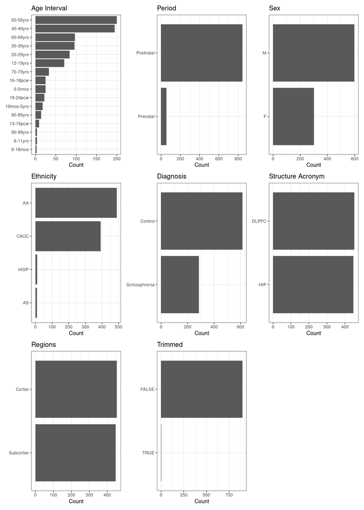

Barplot showing counts of categorial metadata for BrainSeq

```r
wrap_plots(res$categorical_plots, ncol = 3)
```

- Numerical values

```r
res$numeric_summary %>% DT::datatable(caption = "Summary statistics for the selected numerical BrainSeq metadata, including number of samples per category, range of numerical distributions and number of samples with NAs.")
```

|  | column | n | n_na | min | q1 | median | mean | q3 | max | sd |
| --- | --- | --- | --- | --- | --- | --- | --- | --- | --- | --- |
| 1 | Age (Numeric) | 900 | 0 | -0.49863 | 24.54 | 45.43 | 40.28990022161445 | 54.86 | 96.92 | 21.24012928897754 |
| 2 | Dev Replicating (BrainSeq) | 900 | 0 | -4.042881152105862e-17 | -2.65424921171253e-18 | -1.705331369207698e-18 | 0.01853818828080519 | -1.030493010165364e-18 | 0.6244445600170951 | 0.08138406063320013 |
| 3 | Dev Quiescent (BrainSeq) | 900 | 0 | -7.921830981169097e-18 | 0 | 1.089936447450082e-18 | 0.04353229965789109 | 0.01955701171306875 | 0.7313917225804681 | 0.121768166707322 |
| 4 | Adult OPC (BrainSeq) | 900 | 0 | -2.609985283165766e-17 | -6.6950980922623e-18 | -1.529738931510613e-18 | 0.001179873417917827 | 0 | 0.06511466958468151 | 0.006247143384638113 |
| 5 | Adult Neurons (BrainSeq) | 900 | 0 | 0 | 0.3433341732749547 | 0.4012564560961871 | 0.3834344963922029 | 0.4569089157031477 | 0.6533164930474824 | 0.1089170701450765 |
| 6 | Adult Astrocytes (BrainSeq) | 900 | 0 | -5.528479712243853e-18 | 0.2150044941807523 | 0.2393331828242275 | 0.2282010872359304 | 0.2595208894475552 | 0.5292457435549233 | 0.06832366971788575 |
| 7 | Adult Oligo (BrainSeq) | 900 | 0 | -2.908019289418521e-17 | 0.1664692981956443 | 0.2269215969454592 | 0.2111097971286082 | 0.2675828585772142 | 0.5338759120599338 | 0.0944627728720766 |
| 8 | Adult Microglia (BrainSeq) | 900 | 0 | -1.860211177042428e-17 | 2.981476281079048e-18 | 0.02206130818016433 | 0.03224518796411573 | 0.05168910777357019 | 0.2093829600275559 | 0.0379977376733829 |
| 9 | Adult Endothelial (BrainSeq) | 900 | 0 | -5.562379410354645e-19 | 0.04889764729036176 | 0.06984031671265814 | 0.08175906992252864 | 0.1016477930884802 | 0.4556464184805787 | 0.05396028341848939 |
| 10 | Total N Reads | 900 | 0 | 23822582.04804215 | 103272840 | 123786812 | 125990288.2058603 | 143260218 | 374809562 | 40334023.30377492 |

[output cut: 7 more lines]

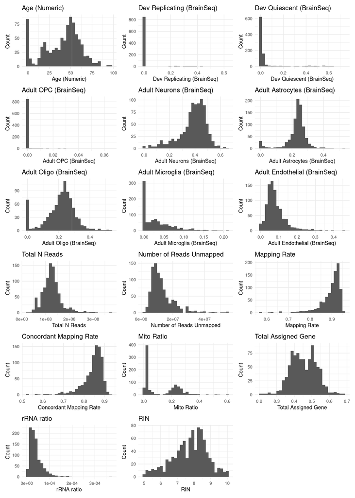

Histogram showing distribution of numerical metadata.

```r
wrap_plots(res$numeric_plots, ncol = 3)
```

### Gene expression pre-processing

```r
exp = rse_gene@assays@.xData$data$rpkm
rownames(exp) <- sub("\\.[0-9]*$", "", rownames(exp))
```

### Export data

```r
#write.csv(exp, file = file.path(bseq.out, "BrainSeq-exp.csv"))
#write.csv(md, file = file.path(bseq.out, "BrainSeq-metadata.csv"))
write.csv(md, file = file.path(here::here("output/metadata"), "BrainSeq-metadata.csv"))
write.csv(bseq.order , file = file.path(here::here("data/annotations"), "BrainSeq-annot-final.csv"))
```

## BrainSpan

The [expression matrix](http://www.brainspan.org/api/v2/well_known_file_download/267666525) and [metadata](http://www.brainspan.org/api/v2/well_known_file_download/267666525) were downloaded from the [BrainSpan Developmental Altas](https://www.brainspan.org/rnaseq/search/index.html). Additional metadata which includes sequencing metrics including PMI, RIN and pH was downloaded from the [Allen Brain Atlas](https://help.brain-map.org/download/attachments/3506181/Human_Brain_Seq_Stages.pdf?).

### Metadata pre-processing

```r
bspan.annot = read.csv(here::here("data/annotations/BrainSpan-metadata-annot.csv"),
                       header = TRUE,
                       check.names = FALSE)

columns.metadata = read.csv(file.path(paths$bulk$raw$brainspan, "columns_metadata.csv"), header = TRUE)
exp = read.csv(file.path(paths$bulk$raw$brainspan, "expression_matrix.csv"),
               header= FALSE, row.names= 1)
rows.metadata = read.csv(file.path(paths$bulk$raw$brainspan, "rows_metadata.csv"))
```

```r
columns.metadata = rename_from_annot(columns.metadata, bspan.annot)

md = columns.metadata %>%
      mutate(Stage = add_feature(.$Age, stages),
             `Age Interval` = add_feature(.$Age, age_intervals),
             Age = gsub(" ","_", .$Age)) %>%
      mutate(SampleID = paste(DonorID, Age, `Structure Acronym`, Stage, sep = "_"),
             DonorName = gsub("\\.","_", .$DonorName),
            `Structure Acronym` = gsub("DFC", "DLPFC", `Structure Acronym`),
            `Structure Acronym` = gsub("MFC", "ACC", `Structure Acronym`)) %>%  ## Changed this for consistency across the datasets
  mutate(Regions = add_feature(.$`Structure Acronym`, regions)) %>%
    mutate(
    `Age (Numeric)` = case_when(
      str_detect(Age, regex("pcw", ignore_case = TRUE)) ~
        (as.numeric(str_remove(Age, "_pcw")) - 40) / 52,
      str_detect(Age, regex("mos", ignore_case = TRUE)) ~
        as.numeric(str_remove(Age, "_mos")) / 12,
      str_detect(Age, regex("yrs", ignore_case = TRUE)) ~
        as.numeric(str_remove(Age, "_yrs")),
      TRUE ~ NA_real_
    )
  ) %>% mutate(Period = ifelse(.$`Age (Numeric)` >= 0, "Postnatal", "Prenatal"),
                   colname = paste(DonorName, Age, `Structure Acronym`, sep = "_"))
```

```r
md.excel = read_excel(here::here("data/annotations/BrainSpan-additional.xlsx"),sheet =2, col_names = TRUE, skip =1) %>%
      as.data.frame() %>% mutate_at(.vars = "AllenInstituteID",
                                    .funs = gsub, pattern = "\\.", replacement = "\\_") %>%
      mutate_at(.vars = "Age", .funs = gsub, pattern = "PCW", replacement = "_pcw") %>%
      mutate_at(.vars = "Age", .funs = gsub, pattern = "M", replacement = "_mos") %>%
      mutate_at(.vars = "Age", .funs = gsub, pattern = "Y", replacement = "_yrs") %>%
      mutate_at(.vars = "Region/Area", .funs = gsub, pattern = "\\/", replacement = "-") %>%
      mutate(colname = paste(AllenInstituteID, Age, `Region/Area`, sep = "_")) %>%
      dplyr::select(-c(Agerange, Age, Description))

md = md %>%
      left_join(.,md.excel, by = "colname", keep = TRUE)
```

```r
md.excel = read_excel(here::here("data/annotations/BrainSpan-additional.xlsx"), sheet = 1, col_names = TRUE) %>%
      as.data.frame() %>%
      mutate_at(.vars="Internal ID", .funs = gsub, pattern = "\\.", replacement = "\\_") %>%
      dplyr::rename("Braincode" = "External ID")

md %<>%
  left_join(md.excel, by ="Braincode") %>%
      dplyr::select(-c("Age.y", "colname.y", "colname.x", "Gender", AllenInstituteID,
                     "Region/Area", "Internal ID")) %>%
      dplyr::rename("Ethnicity"="Ethn.")  %>%
  distinct(SampleID, .keep_all = TRUE)



md = md[!duplicated(md[,c('column_num')]),]
md %<>%
      dplyr::arrange(column_num)

md %<>%
  dplyr::select(-DonorID) %>% ## DonorID is numeric but DonorName is character, so replacing this
  dplyr::rename(DonorID = DonorName,
                `PMI (hours)` = "PMI",
                `Dissection Score` = Dissectionscore) %>%
  mutate(
  Ethnicity = recode(
    Ethnicity,
    "E"   = "CAUC",
    "H"   = "HISP",
    "As"  = "AS",
    "A"   = "AA",
    "A/E" = "Multiracial",
    .default = Ethnicity
  )
) %>%
  mutate( `PMI (hours)` = as.numeric( `PMI (hours)`),
          `Dissection Score` = as.numeric(`Dissection Score`),
          `pH` = as.numeric(`pH`))
```

After harmonization of metadata, a series of exploratory analyses, including correlation analysis was performed to remove redundant or non-informative metadata.

For categorical metadata, a table is shown below which total number of unique values in each category.

```r
cat_tbl <- cat_summary(md, max_show = 50)


cat_tbl %>% as.data.frame() %>% DT::datatable()
```

|  | column | n_unique | values |
| --- | --- | --- | --- |
| 1 | DonorID | 42 | H376_IIA_50, H376_IIA_51, H376_IIB_50, H376_IIB_51, H376_IIB_52, H376_IIIA_50, H376_IIIA_51, H376_IIIA_52, H376_IIIB_50, H376_IIIB_51, H376_IIIB_52, H376_IIIB_53, H376_IV_50, H376_IV_51, H376_IV_53, H… |
| 2 | Age.x | 31 | 1_yrs, 10_mos, 11_yrs, 12_pcw, 13_pcw, 13_yrs, 15_yrs, 16_pcw, 17_pcw, 18_yrs, 19_pcw, 19_yrs, 2_yrs, 21_pcw, 21_yrs, 23_yrs, 24_pcw, 25_pcw, 26_pcw, 3_yrs, 30_yrs, 35_pcw, 36_yrs, 37_pcw, 37_yrs, 4_m… |
| 3 | Sex | 2 | F, M |
| 4 | Structure Acronym | 26 | A1C, ACC, AMY, CB, CBC, CGE, DLPFC, DTH, HIP, IPC, ITC, LGE, M1C, M1C-S1C, MD, MGE, Ocx, OFC, PCx, S1C, STC, STR, TCx, URL, V1C, VFC |
| 5 | Structure | 26 | amygdaloid complex, anterior (rostral) cingulate (medial prefrontal) cortex, caudal ganglionic eminence, cerebellar cortex, cerebellum, dorsal thalamus, dorsolateral prefrontal cortex, hippocampus (hi… |
| 6 | Stage | 14 | s10, s11, s12, s13, s2a, s2b, s3a, s3b, s4, s5, s6, s7, s8, s9 |
| 7 | Age Interval | 14 | 0-5mos, 10-12pcw, 12-19yrs, 13-15pcw, 16-18pcw, 19-24pcw, 19mos-5yrs, 20-29yrs, 25-38pcw, 30-39yrs, 40-49yrs, 6-11yrs, 6-18mos, 8-9pcw |
| 8 | SampleID | 524 | &gt; 50 |
| 9 | Regions | 3 | Cerebellum, Cortex, Subcortex |
| 10 | Period | 2 | Postnatal, Prenatal |

[output cut: 3 more lines]

For sequencing metrics, a correlation analysis was performed using the `corrplot` R package.

```r
seq_cols <- get_seq_metrics_cols(bspan.annot)
seq_cols <- intersect(seq_cols, colnames(md))
```

```r
res <- select_seq_metrics(
  md = md,
  seq_cols = seq_cols,
  corr_thresh = 0.95,
  missing_thresh = 0.5,
  min_unique = 2,
  prefer = "less_missing"
)

res$summary %>% DT::datatable()
```

|  | Metric | class | n_total | n_missing | frac_missing | n_unique_nonmissing | keep_final | drop_reason_final |
| --- | --- | --- | --- | --- | --- | --- | --- | --- |
| 1 | RIN | numeric | 524 | 157 | 0.2996183206106871 | 40 | True |  |
| 2 | pH | numeric | 524 | 221 | 0.4217557251908397 | 26 | True |  |
| 3 | PMI (hours) | numeric | 524 | 157 | 0.2996183206106871 | 18 | True |  |
| 4 | Dissection Score | numeric | 524 | 157 | 0.2996183206106871 | 3 | True |  |

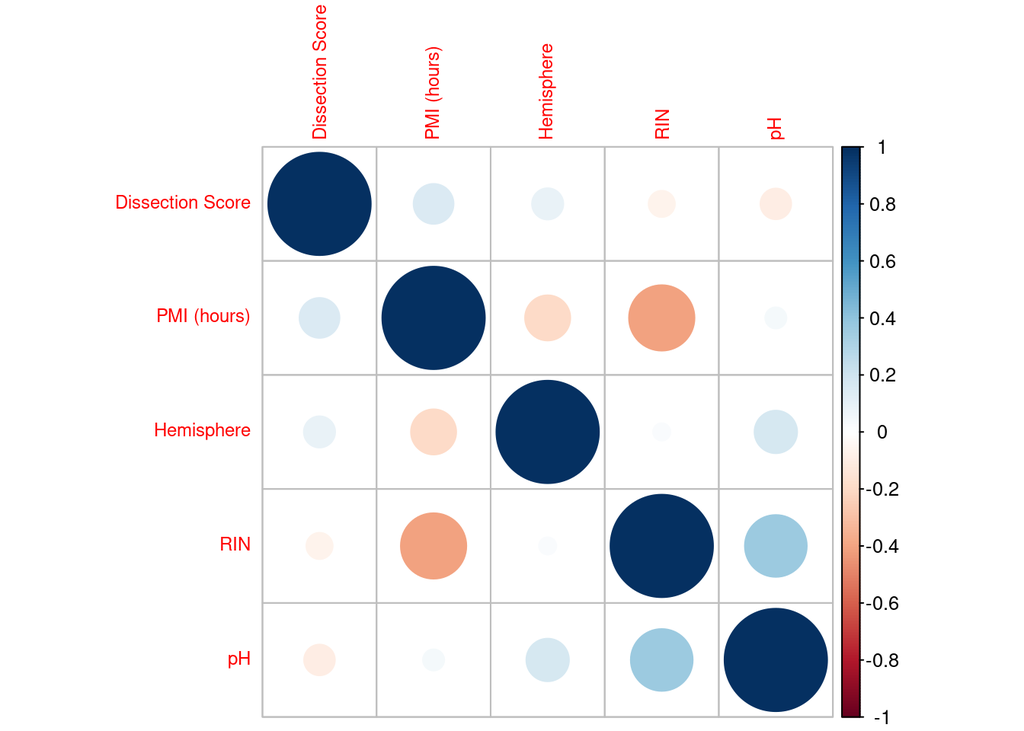

Correlation plot sequencing metrics in BrainSpan

```r
md.clean = md %>%
  dplyr::select(contains(seq_cols))
#md.clean = md.clean %>% select_if(~ !any(is.na(.)))
md.clean = md.clean[vapply(md.clean, function(x) length(unique(x)) > 1, logical(1L))]

M = cor(data.matrix(md.clean), use = "complete.obs")
corrplot(M, order='hclust',
         method = "circle",
         number.cex = .50,
         tl.cex=0.75)
```

Other than BrainCode, no metadata variables were removed from the BrainSpan meatdata.

```r
bspan.order = bspan.annot %>%
  dplyr::filter(`Include (Yes/No) - Interest` == "Yes" | BITColumnName == "Dissection Score") %>%
  arrange(factor(Type, levels = order_vec)) %>%
  mutate(BITColumnName = ifelse(BITColumnName == "DonorName", "DonorID", BITColumnName)) %>%
  arrange(factor(BITColumnName, levels = c("Age Interval",
                                          "Age (Numeric)",
                                          "Period",
                                          "DonorID",
                                          "Sex",
                                          "Ethnicity",
                                          "Diagnosis",
                                          "Structure Acronym",
                                          "Regions",
                                          "SampleID",
                                          "Proportion of Neurons (MultiBrain)",
                                          "Proportion of Astrocytes (MultiBrain)",
                                          "Proportion of Microglia (MultiBrain)",
                                          "Proportion of Oligodendrocytes (MultiBrain)",
                                          "Proportion of Endothelia (MultiBrain)"
                                          )))
```

```r
md %>%
  dplyr::select(contains(bspan.order$BITColumnName)) %>%
  DT::datatable(caption = "BrainSpan Metadata after harmonizing column names, ages and structure acronyms")
```

|  | Age Interval | Age (Numeric) | Period | DonorID | Sex | Ethnicity | Structure Acronym | Regions | SampleID | Hemisphere | RIN | Dissection Score | PMI (hours) | pH |
| --- | --- | --- | --- | --- | --- | --- | --- | --- | --- | --- | --- | --- | --- | --- |
| 1 | 8-9pcw | -0.6153846153846154 | Prenatal | H376_IIA_51 | M |  | Ocx | Cortex | 13058_8_pcw_Ocx_s2a |  |  |  |  |  |
| 2 | 8-9pcw | -0.6153846153846154 | Prenatal | H376_IIA_51 | M | CAUC | M1C-S1C | Cortex | 13058_8_pcw_M1C-S1C_s2a | R | 10 | 5 | 1 | 6.94 |
| 3 | 8-9pcw | -0.6153846153846154 | Prenatal | H376_IIA_51 | M | CAUC | AMY | Subcortex | 13058_8_pcw_AMY_s2a | R | 9.9 | 3 | 1 | 6.94 |
| 4 | 8-9pcw | -0.6153846153846154 | Prenatal | H376_IIA_51 | M | CAUC | MGE | Cortex | 13058_8_pcw_MGE_s2a | R | 10 | 4 | 1 | 6.94 |
| 5 | 8-9pcw | -0.6153846153846154 | Prenatal | H376_IIA_51 | M |  | STC | Cortex | 13058_8_pcw_STC_s2a |  |  |  |  |  |
| 6 | 8-9pcw | -0.6153846153846154 | Prenatal | H376_IIA_51 | M | CAUC | URL | Cerebellum | 13058_8_pcw_URL_s2a | R | 9.9 | 4 | 1 | 6.94 |
| 7 | 8-9pcw | -0.6153846153846154 | Prenatal | H376_IIA_51 | M | CAUC | CGE | Subcortex | 13058_8_pcw_CGE_s2a | R | 10 | 3 | 1 | 6.94 |
| 8 | 8-9pcw | -0.6153846153846154 | Prenatal | H376_IIA_51 | M | CAUC | DTH | Subcortex | 13058_8_pcw_DTH_s2a | R | 9.9 | 5 | 1 | 6.94 |
| 9 | 8-9pcw | -0.6153846153846154 | Prenatal | H376_IIA_51 | M |  | ACC | Cortex | 13058_8_pcw_MFC_s2a |  |  |  |  |  |
| 10 | 8-9pcw | -0.6153846153846154 | Prenatal | H376_IIA_51 | M |  | DLPFC | Cortex | 13058_8_pcw_DFC_s2a |  |  |  |  |  |

[output cut: 514 more lines]

```r
md %<>%
  dplyr::select(contains(bspan.order$BITColumnName)) %>%
  dplyr::select(SampleID, everything())
```

In total BrainSpan contains 14 metadata columns. Here is the metadata summary:

- Categorical values

```r
res <- profile_df(md)
res$categorical_tables %>%
  do.call(rbind,.) %>%
  DT::datatable(caption = "Summary for the selected categorial BrainSpan metadata, including number of samples per category and total proprotion of samples in the category")
```

|  | column | .x | n | prop |
| --- | --- | --- | --- | --- |
| Age Interval.1 | Age Interval | 16-18pcw | 53 | 0.1011450381679389 |
| Age Interval.2 | Age Interval | 12-19yrs | 50 | 0.09541984732824428 |
| Age Interval.3 | Age Interval | 30-39yrs | 48 | 0.0916030534351145 |
| Age Interval.4 | Age Interval | 10-12pcw | 45 | 0.08587786259541985 |
| Age Interval.5 | Age Interval | 13-15pcw | 44 | 0.08396946564885496 |
| Age Interval.6 | Age Interval | 19mos-5yrs | 44 | 0.08396946564885496 |
| Age Interval.7 | Age Interval | 19-24pcw | 43 | 0.08206106870229007 |
| Age Interval.8 | Age Interval | 6-11yrs | 41 | 0.07824427480916031 |
| Age Interval.9 | Age Interval | 0-5mos | 33 | 0.06297709923664122 |
| Age Interval.10 | Age Interval | 20-29yrs | 30 | 0.05725190839694656 |

[output cut: 88 more lines]

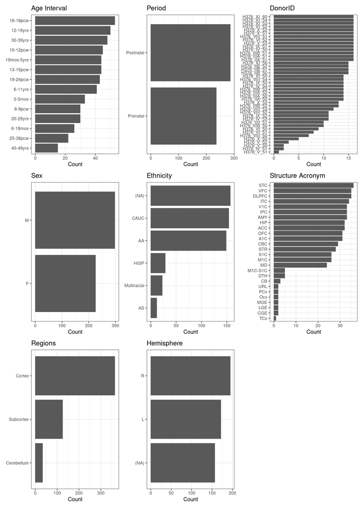

Barplot showing counts of categorial metadata for BrainSpan

```r
wrap_plots(res$categorical_plots, ncol = 3)
```

- Numerical values

```r
res$numeric_summary %>% DT::datatable(caption = "Summary statistics for the selected numerical BrainSpan metadata, including number of samples per category, range of numerical distributions and number of samples with NAs.")
```

|  | column | n | n_na | min | q1 | median | mean | q3 | max | sd |
| --- | --- | --- | --- | --- | --- | --- | --- | --- | --- | --- |
| 1 | Age (Numeric) | 524 | 0 | -0.6153846153846154 | -0.4615384615384616 | 0.3333333333333333 | 7.924520454100607 | 13 | 40 | 12.39095879782506 |
| 2 | RIN | 367 | 157 | 5.4 | 8.5 | 9.2 | 8.960490463215258 | 9.6 | 10 | 0.8746851294771585 |
| 3 | Dissection Score | 367 | 157 | 3 | 5 | 5 | 4.754768392370572 | 5 | 5 | 0.4901465023361143 |
| 4 | PMI (hours) | 367 | 157 | 1 | 1 | 10.5 | 10.89373297002725 | 18 | 30.5 | 9.533927852105652 |
| 5 | pH | 303 | 221 | 5.69 | 6.34 | 6.52 | 6.493894389438944 | 6.81 | 6.94 | 0.3278810387388143 |

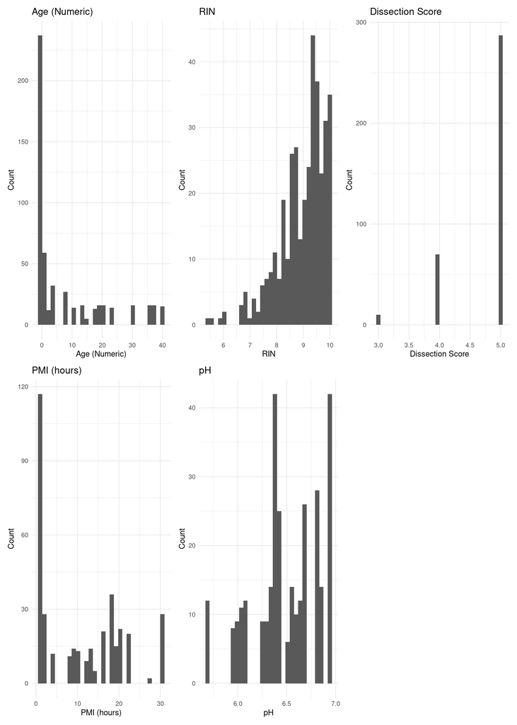

Histogram showing distribution of numerical metadata.

```r
wrap_plots(res$numeric_plots, ncol = 3)
```

### Expression data

```r
colnames(exp) = md$SampleID
rownames(exp) <- rows.metadata$ensembl_gene_id
```

### Export

```r
#write.csv(exp, file = file.path(paths$bulk$formatted$brainspan, "BrainSpan-exp.csv"))
#write.csv(md, file = file.path(paths$bulk$formatted$brainspan,  "BrainSpan-metadata.csv"))
write.csv(md, file = file.path(here::here("output/metadata"), "BrainSpan-metadata.csv"))
write.csv(bspan.order, file = file.path(here::here("data/annotations"), "BrainSpan-annot-final.csv"))
```

## GTEx

The GTEx dataset provides RNA-seq profiles across a broad range of adult human tissues, including from several regions of the brain.

Gene expression data and associated sample-level metadata were retrieved directly from the GTEx portal. For inclusion in BITHub, the dataset was subset to retain brain samples only, with non-brain tissues excluded.

```r
gtex.annot = read.csv(here::here("data/annotations/GTEx-metadata-annot.csv"),
                      header = TRUE,
                      check.names= FALSE)

attributes = list.files(paths$bulk$raw$gtex, full.names = TRUE, pattern = "\\SampleAttributesDS.txt") # Sample attributes contains sample level information
phenotype = list.files(paths$bulk$raw$gtex, full.names = TRUE, pattern = "\\SubjectPhenotypesDS.txt") # Phenotype level information related to each donor
```

```r
md.attrbutes = read_tsv(attributes, col_types = c('.default' = 'c')) %>%
      dplyr::filter(SMTS == 'Brain') %>%
      mutate(SUBJID = sapply(str_split(SAMPID, pattern = "-"),
                             function(x) paste(x[1:2], collapse = '-'))) %>%
  left_join(read_tsv(phenotype, col_types = c('.default' = 'c')))  %>%
  as.data.frame()


md.attrbutes = rename_from_annot(md.attrbutes, gtex.annot)

md.attrbutes %<>%
  as.data.frame() %>%
  mutate(`Structure Acronym` = add_feature(.$`Structure Acronym`, structure_acronym)) %>%
      mutate(Regions = add_feature(.$`Structure Acronym`, regions),
             `Age Interval` = paste(.$`Age Interval`, "yrs", sep = ""),
             Sex = ifelse(Sex == 1, "M", "F"), ## Information taken from the corresponding excel sheet provided
             Period = "Postnatal") %>%
  as.data.frame() %>%
  mutate(
    `PMI (hours)` = as.numeric(`PMI (hours)`) / 60,

    `Hardy Scale` = recode(
      as.character(`Hardy Scale`), ## Coded from GTEx excel sheet
      "0" = "Ventilator Case",
      "1" = "Violent and fast death",
      "2" = "Fast death of natural causes",
      "3" = "Intermediate Death",
      "4" = "Natural Death",
      .default = as.character(`Hardy Scale`)
    ),

    `Autolysis Score` = recode(
      as.character(`Autolysis Score`), ## Coded from GTEx excel sheet
      "0" = "None",
      "1" = "Mild",
      "2" = "Moderate",
      "3" = "Severe",
      .default = as.character(`Autolysis Score`)
    )
  )
```

```r
exp = list.files(paths$bulk$raw$gtex, full.names = TRUE, pattern = "\\gene_tpm.gct.gz") # File used for expression matrix

exp = read.delim(exp, skip = 2)
colnames(exp) <- gsub("\\.", "-", colnames(exp)) # Changing expression file names to match metadata SampleIDs
exp %<>% column_to_rownames("Name")

exp = exp %>%
      dplyr::select(contains(md.attrbutes$SampleID))
message(paste0("Samples subsetted - Exp matrix contains ", ncol(exp), " samples"))
rownames(exp) <- sub("\\.[0-9]*$", "", rownames(exp))

md.attrbutes= md.attrbutes[which(md.attrbutes$SampleID %in% colnames(exp)),]  ## Only keeping sampleIDs which are present in the expression matrix
```

After harmonization of metadata, a series of exploratory analyses, including correlation analysis was performed to remove redundant or non-informative metadata.

For categorical metadata, a table is shown below which total number of unique values in each category.

```r
cat_tbl <- cat_summary(md.attrbutes, max_show = 50)


cat_tbl %>% as.data.frame() %>% DT::datatable()
```

|  | column | n_unique | values |
| --- | --- | --- | --- |
| 1 | SampleID | 2642 | &gt; 50 |
| 2 | Autolysis Score | 5 | (NA), Mild, Moderate, None, Severe |
| 3 | BSS Collection side code | 7 | B1, B1, A1, C1, C1, A1, C1, B1, A1, D1, D1, A1 |
| 4 | PathologyNotes | 231 | &gt; 50 |
| 5 | RIN | 48 | 10, 5, 5.1, 5.3, 5.4, 5.5, 5.6, 5.7, 5.8, 5.9, 6, 6.1, 6.2, 6.3, 6.4, 6.5, 6.6, 6.7, 6.8, 6.9, 7, 7.1, 7.2, 7.3, 7.4, 7.5, 7.6, 7.7, 7.8, 7.9, 8, 8.1, 8.2, 8.3, 8.4, 8.5, 8.6, 8.7, 8.8, 8.9, 9, 9.1, 9… |
| 6 | Regions | 4 | Cerebellum, Cortex, Spinal Cord, Subcortex |
| 7 | Structure Acronym | 13 | ACC, AMY, CAU, CB, CBC, CTX, DLPFC, HIP, HYP, NAC, PUT, SCI, SNA |
| 8 | UberonID | 12 | 0001870, 0001873, 0001874, 0001876, 0001882, 0001898, 0001954, 0002037, 0002038, 0006469, 0009834, 0009835 |
| 9 | Time spent in PAXgene fixative (mins) | 387 | &gt; 50 |
| 10 | Sequencing Batch | 391 | &gt; 50 |

[output cut: 57 more lines]

For sequencing metrics, a correlation analysis was performed for flagging potentially redundant variables.

```r
seq_cols <- get_seq_metrics_cols(gtex.annot)
seq_cols <- intersect(seq_cols, colnames(md.attrbutes))
```

```r
res <- select_seq_metrics(
  md = md.attrbutes,
  seq_cols = seq_cols,
  corr_thresh = 0.95,
  missing_thresh = 0.5,
  min_unique = 2,
  prefer = "less_missing"
)

res$summary %>% DT::datatable(caption = "Summary and correlation of all seqeuncing metrics metadata in GTEx")
```

|  | Metric | class | n_total | n_missing | frac_missing | n_unique_nonmissing | keep_final | drop_reason_final |
| --- | --- | --- | --- | --- | --- | --- | --- | --- |
| 1 | rRNA | character | 2642 | 0 | 0 | 2642 | True |  |
| 2 | Failed_vendor_QC_check | character | 2642 | 0 | 0 | 2640 | True |  |
| 3 | SplitReads | character | 2642 | 0 | 0 | 2640 | True |  |
| 4 | Chimeric Pairs | character | 2642 | 0 | 0 | 2638 | True |  |
| 5 | AlternativeAlignments | character | 2642 | 0 | 0 | 2638 | True |  |
| 6 | rRNA ratio | character | 2642 | 0 | 0 | 2635 | True |  |
| 7 | End 2 Mismatch Rate | character | 2642 | 0 | 0 | 2634 | True |  |
| 8 | Total N Reads | character | 2642 | 0 | 0 | 2631 | True |  |
| 9 | MismatchRate | character | 2642 | 0 | 0 | 2627 | True |  |
| 10 | Expression Profiling Efficiency | character | 2642 | 0 | 0 | 2609 | True |  |

[output cut: 41 more lines]

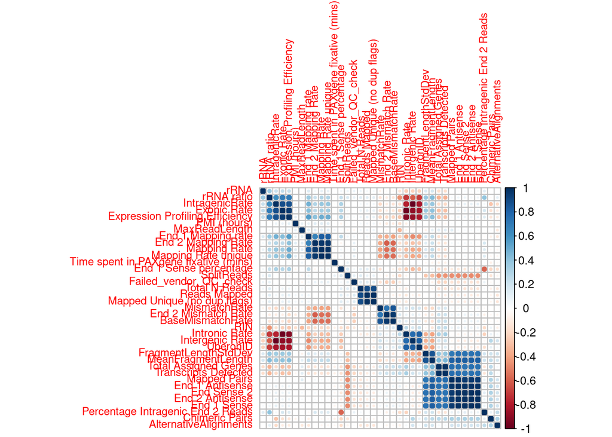

Correlation plot showing highly correlating metadata variables in GTEx

```r
md.clean = md.attrbutes %>%
  dplyr::select(contains(seq_cols))
#md.clean = md.clean %>% select_if(~ !any(is.na(.)))
md.clean = md.clean[vapply(md.clean, function(x) length(unique(x)) > 1, logical(1L))]

M = cor(data.matrix(md.clean), use = "complete.obs")
corrplot(M, order='hclust',
         method = "circle",
         number.cex = .50,
         tl.cex=0.75)
```

Although several sequencing metrics were flagged for removal in the final metadata matrix, they were retained where they corresponded to standard quality control measures that provide relevant technical or experimental context.

```r
gtex.order = gtex.annot %>%
  dplyr::filter(`Include (Yes/No) - Interest` == "Yes") %>%
  mutate(Type = ifelse(Type == "Sample charactertics", "Sample characteristics", Type)) %>% ## In case there is any misspelling
  arrange(factor(Type, levels = order_vec)) %>%
  mutate(BITColumnName = ifelse(BITColumnName == "DonorName", "DonorID", BITColumnName)) %>%
  arrange(factor(BITColumnName, levels = c( "SampleID",
                                          "Age Interval",
                                          "Age (Numeric)",
                                          "Period",
                                          "DonorID",
                                          "Hardy Scale",
                                          "Sex",
                                          "Ethnicity",
                                          "Diagnosis",
                                          "Structure Acronym",
                                          "Regions",
                                          "Autolysis Score",
                                          "Sequencing Batch",
                                          "Type of Batch",
                                          "Date of Batch",
                                          "Genotype or Expression Batch ID",
                                          "Date of Genotype or Expression Batch",
                                          "Type of Genotype or Expression Batch",
                                          "BSS Collection side code",
                                          "Proportion of Neurons (MultiBrain)",
                                          "Proportion of Astrocytes (MultiBrain)",
                                          "Proportion of Microglia (MultiBrain)",
                                          "Proportion of Oligodendrocytes (MultiBrain)",
                                          "Proportion of Endothelia (MultiBrain)"
                                          )))
```

```r
md.attrbutes %>%
  dplyr::select(contains(gtex.order$BITColumnName)) %>%
  DT::datatable(caption = "GTEx Metadata after harmonizing column names, ages and structure acronyms")
```

|  | SampleID | Age Interval | Period | DonorID | Hardy Scale | Sex | Structure Acronym | Regions | Autolysis Score | Sequencing Batch | Type of Batch | Date of Batch | Genotype or Expression Batch ID | Date of Genotype or Expression Batch | BSS Collection side code | RIN | PMI (hours) | Time spent in PAXgene fixative (mins) | End 2 Mapping Rate | Chimeric Pairs | IntragenicRate | Mapping Rate | Mapping Rate unique | End 1 Mapping rate | Exonic Rate | Total Assigned Genes | Reads Mapped | Intergenic Rate | rRNA | … |
| --- | --- | --- | --- | --- | --- | --- | --- | --- | --- | --- | --- | --- | --- | --- | --- | --- | --- | --- | --- | --- | --- | --- | --- | --- | --- | --- | --- | --- | --- | --- |
| 3 | GTEX-1117F-3226-SM-5N9CT | 60-69yrs | Postnatal | GTEX-1117F | Natural Death | F | CTX | Cortex | Mild | BP-43956 | RNA Extraction from Paxgene-derived Lysate Plate Based | 09/25/2013 | LCSET-4904 | 03/22/2014 | B1 | 6.2 | 23.63333333333333 | 931 | 0.991088 | 282429 | 0.963806 | 0.992538 | 0.992538 | 0.993989 | 0.830713 | 23677 | 8.03926e+07 | 0.0359635 | 5.02476e+06 | … |
| 6 | GTEX-111FC-3126-SM-5GZZ2 | 60-69yrs | Postnatal | GTEX-111FC | Violent and fast death | M | CTX | Cortex | Mild | BP-43693 | RNA Extraction from Paxgene-derived Lysate Plate Based | 09/17/2013 | LCSET-4804 | 03/05/2014 | B1 | 6.1 | 20.35 | 697 | 0.990149 | 245136 | 0.964973 | 0.9929 | 0.9929 | 0.995651 | 0.80945 | 24759 | 9.09096e+07 | 0.0346958 | 3.33104e+06 | … |
| 7 | GTEX-111FC-3326-SM-5GZYV | 60-69yrs | Postnatal | GTEX-111FC | Violent and fast death | M | CB | Cerebellum | Moderate | BP-43507 | RNA Extraction from Paxgene-derived Lysate Plate Based | 09/12/2013 | LCSET-4804 | 03/05/2014 | B1 | 7.1 | 20.35 | 697 | 0.987414 | 382782 | 0.951522 | 0.990794 | 0.990794 | 0.994173 | 0.738563 | 23883 | 7.15337e+07 | 0.0481175 | 1.16071e+06 | … |
| 8 | GTEX-1128S-2726-SM-5H12C | 60-69yrs | Postnatal | GTEX-1128S | Fast death of natural causes | F | CTX | Cortex | Mild | BP-43783 | RNA Extraction from Paxgene-derived Lysate Plate Based | 09/19/2013 | LCSET-4805 | 02/27/2014 | B1 | 6.3 | 17.23333333333333 | 811 | 0.990483 | 400475 | 0.962688 | 0.993186 | 0.993186 | 0.995889 | 0.832066 | 23634 | 8.81721e+07 | 0.0370022 | 4.07208e+06 | … |
| 9 | GTEX-1128S-2826-SM-5N9DI | 60-69yrs | Postnatal | GTEX-1128S | Fast death of natural causes | F | CB | Cerebellum | Mild | BP-43956 | RNA Extraction from Paxgene-derived Lysate Plate Based | 09/25/2013 | LCSET-4904 | 03/22/2014 | B1 | 6.3 | 17.26666666666667 | 809 | 0.991069 | 435871 | 0.93529 | 0.992053 | 0.992053 | 0.993037 | 0.711747 | 22983 | 6.58241e+07 | 0.0644661 | 1.61115e+06 | … |
| 11 | GTEX-117XS-3026-SM-5N9CA | 60-69yrs | Postnatal | GTEX-117XS | Fast death of natural causes | M | CTX | Cortex | Mild | BP-43989 | RNA Extraction from Paxgene-derived Lysate Plate Based | 09/26/2013 | LCSET-4904 | 03/22/2014 | B1 | 6.4 | 16.95 | 437 | 0.992014 | 346781 | 0.967309 | 0.993303 | 0.993303 | 0.994591 | 0.830201 | 24501 | 1.04567e+08 | 0.0323446 | 3.67525e+06 | … |
| 13 | GTEX-117XS-3126-SM-5GIDP | 60-69yrs | Postnatal | GTEX-117XS | Fast death of natural causes | M | CB | Cerebellum | Mild | BP-44261 | RNA Extraction from Paxgene-derived Lysate Plate Based | 10/03/2013 | LCSET-4796 | 02/27/2014 | B1 | 7.2 | 16.96666666666667 | 436 | 0.988669 | 301081 | 0.951371 | 0.990955 | 0.990955 | 0.993241 | 0.734977 | 23003 | 6.1555e+07 | 0.0482285 | 852630 | … |
| 16 | GTEX-1192X-0011-R10a-SM-DO941 | 50-59yrs | Postnatal | GTEX-1192X | Natural Death | M | DLPFC | Cortex |  | BP-42439 | RNA isolation_PAXgene Tissue miRNA | 08/19/2013 | LCSET-10341 | 02/22/2017 | B1, A1 | 8.7 | 12.7 |  | 0.99525 | 903331 | 0.964768 | 0.995944 | 0.995944 | 0.996638 | 0.876919 | 22876 | 9.14115e+07 | 0.0346513 | 2.80219e+06 | … |
| 18 | GTEX-1192X-0011-R5a-SM-DNZZA | 50-59yrs | Postnatal | GTEX-1192X | Natural Death | M | CAU | Subcortex |  | BP-42276 | RNA isolation_PAXgene Tissue miRNA | 08/13/2013 | LCSET-10340 | 02/12/2017 | B1, A1 | 8.5 | 12.7 |  | 0.988557 | 704451 | 0.960401 | 0.992373 | 0.992373 | 0.996189 | 0.839317 | 24937 | 1.08253e+08 | 0.0391607 | 4.87563e+06 | … |
| 19 | GTEX-1192X-0011-R6a-SM-DNZZB | 50-59yrs | Postnatal | GTEX-1192X | Natural Death | M | NAC | Subcortex |  | BP-42276 | RNA isolation_PAXgene Tissue miRNA | 08/13/2013 | LCSET-10340 | 02/12/2017 | B1, A1 | 8.1 | 12.7 |  | 0.988555 | 614676 | 0.961468 | 0.992452 | 0.992452 | 0.99635 | 0.84211 | 24933 | 1.10211e+08 | 0.0381445 | 5.84448e+06 | … |

[output cut: 2632 more lines]

```r
md.attrbutes %<>%
  dplyr::select(contains(gtex.order$BITColumnName)) %>%
dplyr::select(SampleID, everything())
```

In total the GTEx contains 44 metadata columns. Here is the metadata summary:

- Categorical values

```r
res <- profile_df(md.attrbutes)
res$categorical_tables %>%
  do.call(rbind,.) %>%
  DT::datatable(caption = "Summary for the selected categorial GTEx metadata, including number of samples per category and total proprotion of samples in the category")
```

|  | column | .x | n | prop |
| --- | --- | --- | --- | --- |
| Age Interval.1 | Age Interval | 60-69yrs | 1317 | 0.4984859954579864 |
| Age Interval.2 | Age Interval | 50-59yrs | 775 | 0.2933383800151401 |
| Age Interval.3 | Age Interval | 40-49yrs | 259 | 0.09803179409538229 |
| Age Interval.4 | Age Interval | 70-79yrs | 154 | 0.0582891748675246 |
| Age Interval.5 | Age Interval | 20-29yrs | 70 | 0.02649507948523845 |
| Age Interval.6 | Age Interval | 30-39yrs | 67 | 0.02535957607872824 |
| Period | Period | Postnatal | 2642 | 1 |
| Hardy Scale.1 | Hardy Scale | Fast death of natural causes | 1475 | 0.5582891748675246 |
| Hardy Scale.2 | Hardy Scale | Natural Death | 680 | 0.2573807721423164 |
| Hardy Scale.3 | Hardy Scale | Intermediate Death | 199 | 0.0753217259651779 |

[output cut: 84 more lines]

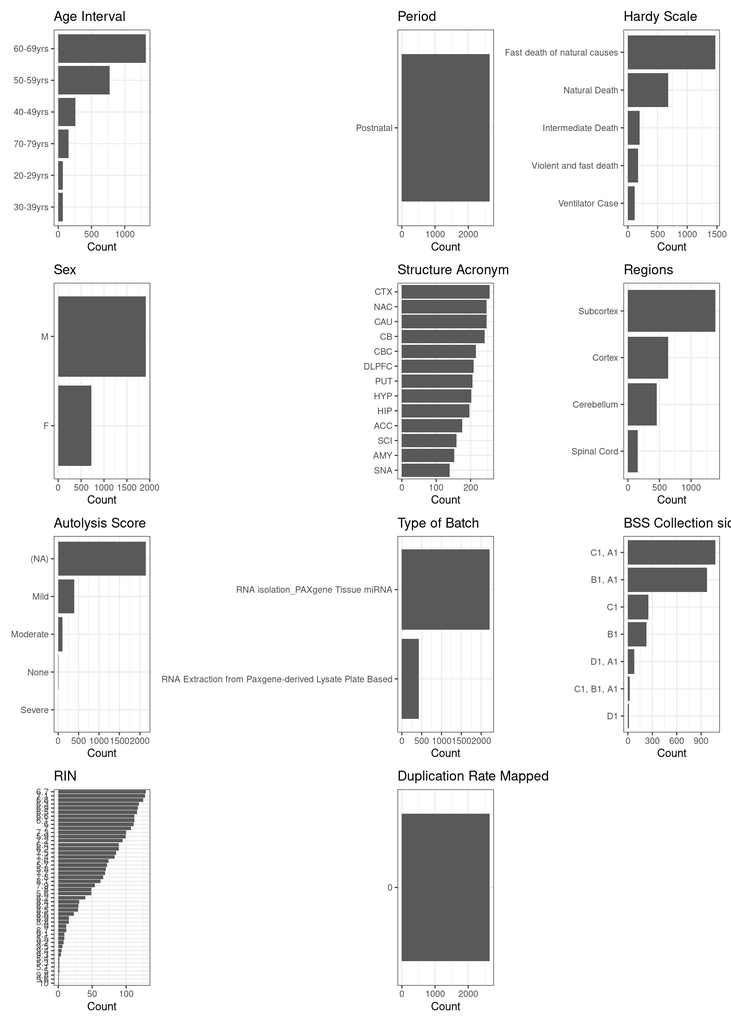

Barplot showing counts of categorial metadata for GTEx

```r
wrap_plots(res$categorical_plots, ncol = 3)
```

- Numerical values

```r
res$numeric_summary %>% DT::datatable(caption = "Summary statistics for the selected numerical GTEx metadata, including number of samples per category, range of numerical distributions and number of samples with NAs.")
```

|  | column | n | n_na | min | q1 | median | mean | q3 | max | sd |
| --- | --- | --- | --- | --- | --- | --- | --- | --- | --- | --- |
| 1 | PMI (hours) | 2642 | 0 | 3.716666666666667 | 10.16666666666667 | 13.41666666666667 | 13.65203759777946 | 17.0125 | 27.81666666666667 | 4.503190812400155 |

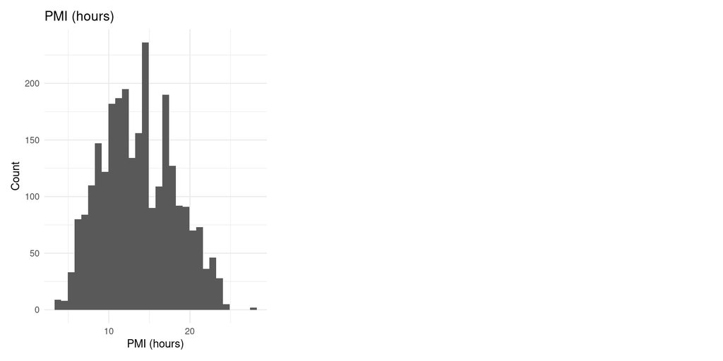

Histogram showing distribution of numerical metadata.

```r
wrap_plots(res$numeric_plots, ncol = 3)
```

### Export files

```r
#write.csv(exp, file = file.path(paths$bulk$formatted$gtex, "GTEx-exp.csv"))
#write.csv(md.attrbutes, file = file.path(paths$bulk$formatted$gtex, "GTEx-metadata.csv"))
write.csv(md.attrbutes, file = file.path(here::here("output/metadata"), "GTEx-metadata.csv"))

write.csv(gtex.order, file = file.path(here::here("data/annotations"), "GTEx-annot-final.csv"))
```

```r
rm(gtex.order)
rm(exp)
rm(md.attrbutes)
```

## HDBR

The Human Developmental Biology Resource (HDBR) dataset comprises human brain RNA-seq samples collected across prenatal developmental stages from multiple anatomical sites.

The gene expression data and corresponding bioinformatics sequencing quality metrics were retrieved from the recount3 R package, which provides uniformly processed and normalized RNA-seq data derived from public repositories.

Additional clinical and sample-level metadata, including developmental and experimental annotations not available in recount3, were obtained from the European Nucleotide Archive (ENA).

```r
hdbr = recount3::create_rse_manual(
  project = "ERP016243",
  type = "gene"
)

hdbr.annot = read.csv(here::here("data/annotations/HDBR-metadata-annot.csv"),
                      header=TRUE,
                      check.names = FALSE)
hdbr_supp = read_excel(file.path(paths$bulk$raw$hdbr,"Amended Supplementary Table 1.xlsx"),
                       sheet = 1, skip =6) %>%
  as.data.frame()
hdbr_phenotype = read.csv(file.path(paths$bulk$raw$hdbr,"hdbr-phenotype.csv"),
                          header=TRUE)

colnames(hdbr_supp) = c("DonorID","Age", "SampleID", "Structure","Hemisphere", "Sex", "PMI")
hdbr_supp %<>% dplyr::select("DonorID","Structure", "PMI")
```

```r
md.hdbr = read.table(file.path(paths$bulk$raw$hdbr, "E-MTAB-4840-experiment-design.tsv"),
                     fill=TRUE, sep = "\t", header=TRUE )
```

```r
md.hdbr = md.hdbr[,1:15]

md.hdbr= rename_from_annot(md.hdbr, hdbr.annot)

md.hdbr %<>%
  as.data.frame() %>%
  dplyr::select(-c(Block, OntologyIndividual,  KaryotypeOntology, Organism, OrganismOntology,
                   StructureOntology, HemisphereOntology, OntologyAge)) %>%
  mutate(`Age Interval` = add_feature(.$Age, age_intervals))  %>%
  dplyr::rename("Structure"= "Structure Acronym") %>%
  left_join(strc_acr, by = "Structure") %>%
  left_join(rgns_ftl, by = "Structure Acronym") %>%
  mutate(Sex = toupper(Sex)) %>%
  mutate(Sex = ifelse(str_detect(Sex,"XX"), "F",
                      ifelse(str_detect(Sex, "XY"), "M", "Unknown" )),
         Period = c("Prenatal")) %>%
    mutate(Hemisphere = gsub("right", "R", Hemisphere),
         Hemisphere = gsub("left", "L", Hemisphere),
         Hemisphere = gsub("frontal", "Frontal", Hemisphere))

md = colData(hdbr) %>%
  as.data.frame() %>%
   dplyr::select(-contains("2"))
md = rename_from_annot(md, hdbr.annot)



hdbr_supp %<>%
  distinct(DonorID, .keep_all = TRUE) %>%
  mutate(PMI = ifelse(PMI == "UNKNOWN", NA, PMI))
md.hdbr %<>%
  left_join(hdbr_supp, by = c("DonorID"))
full.md.hdbr =left_join(md.hdbr, md)
full.md.hdbr %<>%
  mutate(PMI = as.numeric(PMI))

full.md.hdbr %<>%
  dplyr::filter(Structure.x != "stomach") %>%
  mutate(PMI = as.numeric(PMI) /60) %>%
  dplyr::rename(`PMI (hours)` = PMI) %>%
  mutate(DonorID = paste0(DonorID, "_donorID"))
```

```r
cat_tbl <- cat_summary(full.md.hdbr, max_show = 50)


cat_tbl %>% as.data.frame() %>% DT::datatable()
```

|  | column | n_unique | values |
| --- | --- | --- | --- |
| 1 | SampleID | 649 | &gt; 50 |
| 2 | Sequencing Batch | 42 | sequencing batch:FC2014_030, sequencing batch:FC2014_030, FC2014_117, sequencing batch:FC2014_030, FC2014_151, sequencing batch:FC2014_032, sequencing batch:FC2014_032, FC2014_117, sequencing batch:FC… |
| 3 | Age | 23 | 10 post conception weeks, 11 post conception weeks, 12 post conception weeks, 13 post conception weeks, 14 post conception weeks, 15 post conception weeks, 16 post conception weeks, 17 post conception… |
| 4 | DonorID | 189 | &gt; 50 |
| 5 | Sex | 3 | F, M, Unknown |
| 6 | Structure.x | 21 | basal ganglion, brain fragment, cerebellum, cerebral cortex, choroid plexus, diencephalon, diencephalon and midbrain, forebrain, forebrain and midbrain, forebrain fragment, hindbrain, hindbrain fragme… |
| 7 | Hemisphere | 4 | , Frontal, L, R |
| 8 | Age Interval | 6 | 10-12pcw, 13-15pcw, 16-18pcw, 19-24pcw, 4-7pcw, 8-9pcw |
| 9 | Structure Acronym | 21 | BF, CAU, CB, CP, CTX, DIEN, DIEN-MID, FB, FB-MID, FBF, HB, HB/C, HBF, HIP, MB, MEDU, PIT-DIEN, PONS, SCI, TCx, TEL |
| 10 | Regions | 6 | Brain, Chroid plexus, Forebrain, Hindbrain, Midbrain, Spinal Cord |

[output cut: 44 more lines]

```r
seq_cols <- get_seq_metrics_cols(hdbr.annot)
seq_cols <- intersect(seq_cols, colnames(full.md.hdbr))
```

```r
res <- select_seq_metrics(
  md =full.md.hdbr,
  seq_cols = seq_cols,
  corr_thresh = 0.95,
  missing_thresh = 0.5,
  min_unique = 2,
  prefer = "less_missing"
)

res$summary %>% DT::datatable()
```

|  | Metric | class | n_total | n_missing | frac_missing | n_unique_nonmissing | keep_final | drop_reason_final |
| --- | --- | --- | --- | --- | --- | --- | --- | --- |
| 1 | Mode Fragment Length Count | integer | 649 | 0 | 0 | 649 | True |  |
| 2 | Total fragments input fc exon fc | integer | 649 | 0 | 0 | 649 | True |  |
| 3 | Intron Total | numeric | 649 | 0 | 0 | 649 | True |  |
| 4 | Junction count | integer | 649 | 0 | 0 | 649 | True |  |
| 5 | Junction coverage | integer | 649 | 0 | 0 | 649 | True |  |
| 6 | Junction average coverage | numeric | 649 | 0 | 0 | 649 | True |  |
| 7 | SampleBases | numeric | 649 | 0 | 0 | 649 | True |  |
| 8 | Size | numeric | 649 | 0 | 0 | 649 | True |  |
| 9 | ReadInfo | character | 649 | 0 | 0 | 649 | True |  |
| 10 | RunAlias | character | 649 | 0 | 0 | 649 | True |  |

[output cut: 123 more lines]

[figure not shown]

```r
md.clean = full.md.hdbr %>%
  dplyr::select(contains(seq_cols))
#md.clean = md.clean %>% select_if(~ !any(is.na(.)))
md.clean = md.clean[vapply(md.clean, function(x) length(unique(x)) > 1, logical(1L))]

M = cor(data.matrix(md.clean), use = "complete.obs")
corrplot(M, order='hclust',
         method = "circle",
         number.cex = .50,
         tl.cex=0.75)
```

```r
hdbr.order = hdbr.annot %>%
  dplyr::filter(`Include (Yes/No) - Interest` == "Yes") %>%
  mutate(Type = ifelse(Type == "Sample charactertics", "Sample characteristics", Type)) %>%
  arrange(factor(Type, levels = order_vec)) %>%
  mutate(BITColumnName = ifelse(BITColumnName == "DonorName", "DonorID", BITColumnName)) %>%
  arrange(factor(BITColumnName, levels = c("SampleID",
                                          "Age Interval",
                                          "Age (Numeric)",
                                          "Period",
                                          "DonorID",
                                          "Sex",
                                          "Ethnicity",
                                          "Diagnosis",
                                          "Structure Acronym",
                                          "Regions",
                                          "Hemisphere",
                                          "Proportion of Neurons (MultiBrain)",
                                          "Proportion of Astrocytes (MultiBrain)",
                                          "Proportion of Microglia (MultiBrain)",
                                          "Proportion of Oligodendrocytes (MultiBrain)",
                                          "Proportion of Endothelia (MultiBrain)",
                                          "PMI (hours)"
                                          )))
```

```r
full.md.hdbr %>%
  dplyr::select(contains(hdbr.order$BITColumnName)) %>%
  DT::datatable(caption = "HDBR Metadata after harmonizing column names, ages and structure acronyms")
```

|  | SampleID | Age Interval | Period | DonorID | Sex | Structure Acronym | Regions | Hemisphere | PMI (hours) | Sequencing Batch | Chimeric Pairs | Percent aligned ChrX | Percent aligned ChrY | AUC all percentage | AUC unique percentage | Mode Fragment Length Count | Exonic Rate | Total fragments assigned exon fc | Total fragments count unique exon fc | Total fragments count unique assigned exon fc | Total Assigned Gene | Intronic Rate | Percentage mapped multi loci STAR | Percentage mapped too many loci STAR | Percentage unmapped other STAR | Reads Mapped | Total N Reads | Mapping Rate | Mapping Rate unique | … |
| --- | --- | --- | --- | --- | --- | --- | --- | --- | --- | --- | --- | --- | --- | --- | --- | --- | --- | --- | --- | --- | --- | --- | --- | --- | --- | --- | --- | --- | --- | --- |
| 1 | ERR1472952 | 8-9pcw | Prenatal | 11826_donorID | F | CAU | Forebrain | R | 2 | sequencing batch:FC2014_038 | 2.17 | 3.08 | 0.01 | 130.24 | 132.58 | 248186 | 75.1 | 38729316 | 62589023 | 38729316 | 38208838 | 9.12 | 6.21 | 0.06 | 0.03 | 51568896 | 53177214 | 90.76 | 48264169 | … |
| 2 | ERR1472953 | 8-9pcw | Prenatal | 11827_donorID | F | CAU | Forebrain | L | 2 | sequencing batch:FC2014_038 | 1.66 | 2.3 | 0.01 | 126.8 | 133.02 | 192644 | 70.37 | 25726258 | 56483062 | 25726258 | 25625972 | 9.42 | 11.58 | 0.06 | 0.03 | 36560395 | 37282133 | 86.48 | 32242634 | … |
| 3 | ERR1472954 | 8-9pcw | Prenatal | 11827_donorID | F | CAU | Forebrain | R | 2 | sequencing batch:FC2014_038 | 1.9 | 2.87 | 0.01 | 129.56 | 133.59 | 185245 | 74.57 | 27389234 | 49451226 | 27389234 | 27032568 | 8.38 | 8.32 | 0.05 | 0.03 | 36728569 | 37757206 | 88.95 | 33586076 | … |
| 4 | ERR1472955 | 8-9pcw | Prenatal | 11846_donorID | F | CAU | Forebrain | L | 30 | sequencing batch:FC2014_030 | 2.16 | 3.04 | 0.01 | 130.32 | 132.76 | 227702 | 74.51 | 33864292 | 54994666 | 33864292 | 33382117 | 9.05 | 6.16 | 0.06 | 0.03 | 45448477 | 46643320 | 91.28 | 42576845 | … |
| 5 | ERR1472956 | 8-9pcw | Prenatal | 11846_donorID | F | CAU | Forebrain | R | 30 | sequencing batch:FC2014_030 | 2.16 | 3.05 | 0.01 | 130.11 | 132.79 | 183532 | 74.25 | 27803470 | 46081344 | 27803470 | 27396685 | 9.16 | 6.48 | 0.06 | 0.03 | 37444145 | 38413344 | 91 | 34955957 | … |
| 6 | ERR1472957 | 8-9pcw | Prenatal | 11918_donorID | F | CAU | Forebrain | L | 2 | sequencing batch:FC2014_030 | 1.85 | 2.91 | 0.01 | 128.86 | 131.93 | 249098 | 73.46 | 32270067 | 56030670 | 32270067 | 31905748 | 9.47 | 7.16 | 0.06 | 0.03 | 43930257 | 44741577 | 91.02 | 40725633 | … |
| 7 | ERR1472958 | 8-9pcw | Prenatal | 11918_donorID | F | CAU | Forebrain | R | 2 | sequencing batch:FC2014_030 | 1.99 | 2.95 | 0.01 | 129.7 | 133.43 | 271953 | 73.9 | 33800454 | 60482297 | 33800454 | 33442993 | 8.78 | 8 | 0.06 | 0.03 | 45739536 | 46467041 | 90.44 | 42023440 | … |
| 8 | ERR1472959 | 8-9pcw | Prenatal | 11831_donorID | M | CAU | Forebrain | L |  | sequencing batch:FC2014_035 | 2.07 | 3.04 | 0.11 | 128.93 | 130.86 | 200259 | 70.62 | 29586215 | 49434663 | 29586215 | 29107716 | 12.16 | 5.55 | 0.07 | 0.04 | 41897401 | 42575619 | 92.85 | 39532525 | … |
| 9 | ERR1472960 | 8-9pcw | Prenatal | 11831_donorID | M | CAU | Forebrain | R |  | sequencing batch:FC2014_032 | 2.19 | 3.19 | 0.1 | 131.67 | 133.19 | 282862 | 77.87 | 42284756 | 61844483 | 42284756 | 41600066 | 8.06 | 4.97 | 0.06 | 0.02 | 54298412 | 55271732 | 93.27 | 51552927 | … |
| 10 | ERR1472961 | 8-9pcw | Prenatal | 11845_donorID | M | CAU | Forebrain | R | 2 | sequencing batch:FC2014_043, FC2014_117 | 3.09 | 2.97 | 0.11 | 132.23 | 134.33 | 165082 | 77.05 | 23735506 | 36382344 | 23735506 | 23359078 | 7.6 | 5.66 | 0.06 | 0.03 | 30803798 | 31320898 | 92.69 | 29030062 | … |

[output cut: 639 more lines]

```r
full.md.hdbr %<>%
  dplyr::select(contains(hdbr.order$BITColumnName))
```

```r
assay(hdbr, "counts") = transform_counts(hdbr, round = TRUE)

hdbr.tpm = recount::getTPM(hdbr)

filter <- rowSums(hdbr.tpm, na.rm = TRUE) > 0.05
hdbr.filter.tpm = hdbr.tpm[filter,]
hdbr.filter.tpm <- thresh(hdbr.filter.tpm)


hdbr.final = hdbr.tpm %>%
  as.data.frame() %>%
  dplyr::select(contains(full.md.hdbr$SampleID)) %>%
  rownames_to_column("EnsemblID") %>%
  mutate_at(.vars = "EnsemblID", .funs = gsub, pattern = "\\.[0-9]*$", replacement = "")
```

### Export data

```r
#write.csv(hdbr.final, file =file.path(paths$bulk$formatted$hdbr, "HDBR-exp.csv"))
#write.csv(full.md.hdbr, file =file.path(paths$bulk$formatted$hdbr, "HDBR-metadata.csv"))
write.csv(full.md.hdbr, file = file.path(here::here("output/metadata"), "HDBR-metadata.csv"))

write.csv(hdbr.order, file = file.path(here::here("data/annotations"), "HDBR-annot-final.csv"))
```

```r
rm(hdbr.final)
rm(full.md.hdbr)
rm(hdbr.order)
rm(hdbr)
rm(hdbr_phenotype)
```

## PsychENCODE

The PsychENCODE data used for BITHub were obtained from the PsychENCODE Capstone 4 release, a large-scale transcriptomic resource profiling post-mortem human brain tissue across neurotypical individuals and psychiatric disease cohorts. The dataset includes bulk RNA-sequencing data generated primarily from the DLPFC.

The [gene expression matrix](http://resource.psychencode.org/Datasets/Derived/Controls_only_PEC_Gene_expression_matrix_normalized.txt) and corresponding [sample-level metadata](https://www.synapse.org/#!Synapse:syn18915911) were retrieved from the [PsychENCODE Capstone 4 project repository](http://resource.psychencode.org).

In addition, the PsychENCODE release includes pre-computed [cell type proportion estimates derived](http://resource.psychencode.org/Datasets/Derived/SC_Decomp/DER-24_Cell_fractions_Normalized.xlsx) from reference-based deconvolution approaches. These cell-type estimates were downloaded from the PsychENCODE Capstone 4 resource and incorporated into the BITHub preprocessing pipeline.

```r
pe.annot = read.csv(here::here("data/annotations/PsychEncode-metadata-annot.csv"),
                    header=TRUE,
                    check.names = FALSE) %>%
  dplyr::rename(OriginalMetadataColumnName = OriginalColumnName)  %>%
mutate(
     OriginalMetadataColumnName = gsub("\\.", "-", OriginalMetadataColumnName)
    )

md = list.files(paths$bulk$raw$psychencode, full.names = TRUE, pattern = "Job*") %>% read.csv(., header=TRUE) %>%
  dplyr::filter(individualID != "2015-1")
md.clinical = read.csv(file.path(paths$bulk$raw$psychencode, "PEC_capstone_data_map_clinical.csv"), header=TRUE, check.names = FALSE)
```

```r
exp = list.files(paths$bulk$raw$psychencode, full.names = TRUE, pattern = "\\Gene_expression_matrix_TPM.txt") %>%
      read.table(., header=TRUE, row.names = 1, check.names = FALSE)
```

```r
comp = list.files(paths$bulk$raw$psychencode, full.names = TRUE, pattern = "\\Cell_fractions*") %>% read_excel() %>%
      as.data.frame() %>%
      column_to_rownames("CellType")
```

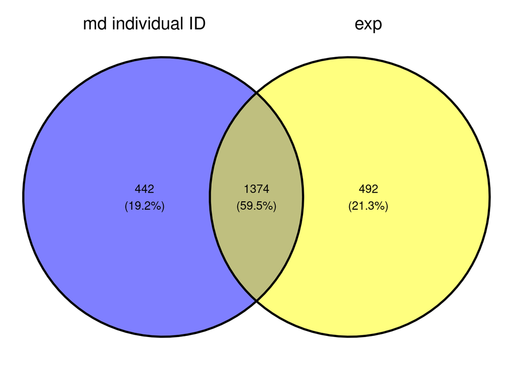

```r
library(VennDiagram)

pe.overlap = list("md individual ID" = md.clinical$`Synapse: individualID`,
                 #  "md pe individual ID" = md.clinical$`resource.psychencode.org: individualID`,
                  # "md original" = md$individualID,
                   "exp" = colnames(exp))
ggvenn(pe.overlap)
```

```r
#x = calculate.overlap(pe.overlap)

#colnames(exp) %>%
 # as.data.frame() %>% dplyr::rename(SampleID = ".") %>%
  #dplyr::filter(!SampleID %in% md$individualID)
```

### Metadata pre-processing

```r
  # Fix existing columns

comp = as.data.frame(t(comp))

md %<>%
 left_join(comp %>% # So only those in the main MD can be used
  tibble::rownames_to_column("individualID"), by= "individualID")

md  = rename_from_annot(md, pe.annot, strict = FALSE)

# PCW to age numeric
md$`Age (Numeric)`[grepl("PCW", md$`Age (Numeric)`, ignore.case = TRUE)] = md$`Age (Numeric)`[grepl("PCW", md$`Age (Numeric)`)] %>%
  str_remove("PCW")%>%
  as.numeric() %>% `-` (40) %>% divide_by(52)

md$`Age (Numeric)` = gsub("90+", "91", md$`Age (Numeric)`)
md$`Age (Numeric)` =gsub("\\+", "", md$`Age (Numeric)`)


md$`Age (Numeric)` <- as.numeric(as.character(md$`Age (Numeric)`))

md %<>%
      dplyr::filter(Diagnosis == "Affective Disorder" |
               Diagnosis == "Autism Spectrum Disorder" |
               Diagnosis == "Bipolar Disorder" |
               Diagnosis == "Control" |
               Diagnosis == "Schizophrenia") %>%
      mutate(Structure = c("Dorsolateral Prefrontal Cortex"),  ## Adding name of structure
             `Structure Acronym` = c("DLPFC")) %>%
      mutate(Period = ifelse(.$`Age (Numeric)` >= 0, "Postnatal", "Prenatal"))  %>%
      mutate(Age_rounded = as.character(sapply(.$`Age (Numeric)`, num_to_round))) %>% as.data.frame() %>%
      mutate(`Age Interval` = as.character(add_feature(.$Age_rounded, age_intervals)),
             `Cause of Death` = as.character(add_feature(.$`Cause of Death`, death_cause))) %>%
      mutate(Regions = c("Cortex")) %>%
      mutate(DonorID = as.character(.$SampleID)) %>%
      dplyr::select(-Age_rounded) %>%
      as.data.frame() %>%
  mutate(Ethnicity = ifelse(Ethnicity == "HiSP", "HISP", Ethnicity))

exp = exp %>%
  dplyr::select(contains(md$SampleID))

md = md %>%
  dplyr::filter(SampleID %in% colnames(exp))
exp = exp[colnames(exp) %in% md$SampleID,]
md = md[md$SampleID %in% colnames(exp),]
```

As PsychENCODE did not contain sequencing metrics, no correlation analysis was performed. and an exploratory analysis of the categoiral metadata was performed to remove redundant data. All numerical metadata in this instance were kept.

```r
cat_tbl <- cat_summary(md, max_show = 50)


cat_tbl %>% as.data.frame() %>% DT::datatable()
```

|  | column | n_unique | values |
| --- | --- | --- | --- |
| 1 | ContributingStudy | 8 | BipSeq, BrainGVEX, BrainSpan, CMC, CMC, EpiDiff, LIBD_szControl, UCLA-ASD, Yale-ASD |
| 2 | SampleID | 1369 | &gt; 50 |
| 3 | individualIDSource | 19 | , Advanced Biosciences Resources, ATP, BSHRI, MSSM, National Disease Research Interchange, NICHD, NIMH, Novogenix, Penn, Pitt, SMRI "Array", SMRI "Consortium", SMRI "Extra", SMRI "New", StemExpress, U… |
| 4 | Diagnosis | 5 | Affective Disorder, Autism Spectrum Disorder, Bipolar Disorder, Control, Schizophrenia |
| 5 | Sex | 3 | , F, M |
| 6 | Ethnicity | 8 | , AA, AS, CAUC, HISP, Multiracial, Non-White, Unknown |
| 7 | Cause of Death | 7 | Accident, Cancer, Cardiac, Illness, Natural, Suicide, Unknown |
| 8 | ageBiopsy | 1 | (NA) |
| 9 | smellTestScore | 1 | (NA) |
| 10 | smoker | 1 | (NA) |

[output cut: 8 more lines]

```r
pe.order = pe.annot %>%
  mutate(`Include (Yes/No) - Interest` = ifelse(BITColumnName == "individualIDSource","Yes", `Include (Yes/No) - Interest`),
         `Include (Yes/No) - Interest` = ifelse(BITColumnName == "DonorID","No", `Include (Yes/No) - Interest`)) %>% ## Amending this after discussion with Irina
  dplyr::filter(`Include (Yes/No) - Interest` == "Yes") %>%
  mutate(Type = ifelse(Type == "Sample charactertics", "Sample characteristics", Type)) %>%
  arrange(factor(Type, levels = order_vec)) %>%
  mutate(BITColumnName = ifelse(BITColumnName == "DonorName", "DonorID", BITColumnName)) %>%
  arrange(factor(BITColumnName, levels = c("SampleID",
                                           "Age Interval",
                                          "Age (Numeric)",
                                          "Period",
                                          "DonorID",
                                          "Sex",
                                          "Ethnicity",
                                          "Cause of Death",
                                          "Brain Weight",
                                          "Height",
                                          "Weight",
                                          "Diagnosis",
                                          "Structure Acronym",
                                          "Regions",
                                          "Capstone_4",
                                           "individualIDSource",
                                          "Proportion of Neurons (MultiBrain)",
                                          "Proportion of Astrocytes (MultiBrain)",
                                          "Proportion of Microglia (MultiBrain)",
                                          "Proportion of Oligodendrocytes (MultiBrain)",
                                          "Proportion of Endothelia (MultiBrain)"
                                          )))
```

```r
md %>%
   DT::datatable(caption = "PsychENCODE Metadata after harmonizing column names, ages and structure acronyms")
```

|  | Row_ID | Row_version | ContributingStudy | SampleID | individualIDSource | Diagnosis | Sex | Ethnicity | Age (Numeric) | ageOnset | Cause of Death | Brain Weight | Height | Weight | ageBiopsy | smellTestScore | smoker | Notes | Capstone_4 | Adult Ex1 (PsychENCODE) | Adult Ex2 (PsychENCODE) | Adult Ex3 (PsychENCODE) | Adult Ex4 (PsychENCODE) | Adult Ex5 (PsychENCODE) | Adult Ex6 (PsychENCODE) | Adult Ex7 (PsychENCODE) | Adult Ex8 (PsychENCODE) | Adult In1 (PsychENCODE) | Adult In2 (PsychENCODE) | … |
| --- | --- | --- | --- | --- | --- | --- | --- | --- | --- | --- | --- | --- | --- | --- | --- | --- | --- | --- | --- | --- | --- | --- | --- | --- | --- | --- | --- | --- | --- | --- |
| 1 | 10 | 17 | BrainSpan | HSB123 |  | Control | M | AA | 37 |  | Unknown |  |  |  |  |  |  |  | true | 0.150534557799979 | 0 | 0 | 0.011945986526462 | 0.126953703569455 | 0 | 0 | 0.0086544110519883 | 0 | 0 | … |
| 2 | 12 | 17 | BrainSpan | HSB126 |  | Control | F | CAUC | 30 |  | Unknown |  |  |  |  |  |  |  | true | 0.158837892219528 | 0 | 0 | 0.0340489238175942 | 0.108282517501215 | 0 | 0 | 0 | 0 | 0 | … |
| 3 | 14 | 17 | BrainSpan | HSB130 |  | Control | F | CAUC | 21 |  | Unknown |  |  |  |  |  |  |  | true | 0.152156925339884 | 0 | 0 | 0.0100643047555686 | 0.127949547706856 | 0 | 0 | 0.0206187687934331 | 0 | 0 | … |
| 4 | 17 | 17 | BrainSpan | HSB135 |  | Control | F | AA | 40 |  | Unknown |  |  |  |  |  |  |  | true | 0.192988913690211 | 0 | 0 | 0.0392540272523888 | 0.0286074764586473 | 0 | 0 | 0 | 0 | 0 | … |
| 5 | 18 | 17 | BrainSpan | HSB136 |  | Control | M | AA | 23 |  | Unknown |  |  |  |  |  |  |  | true | 0.154965683183328 | 0 | 0 | 0 | 0.0435450855446331 | 0 | 0 | 0.0054686001483605 | 0 | 0 | … |
| 6 | 22 | 17 | BrainSpan | HSB145 |  | Control | M | CAUC | 36 |  | Unknown |  |  |  |  |  |  |  | true | 0.170234821574816 | 0 | 0 | 0.0566892472712576 | 0.0934316418026047 | 0 | 0 | 0 | 0 | 0 | … |
| 7 | 40 | 19 | CMC | CMC_MSSM_002 | MSSM | Bipolar Disorder | M | CAUC | 42 |  | Cardiac | 1398 | 68 | 225 |  |  |  |  | true | 0.159714742404522 | 0 | 0.0401148864041503 | 0.04709864883765 | 0.0594124841875614 | 0 | 0 | 0.00850849628335713 | 0 | 0 | … |
| 8 | 41 | 19 | CMC | CMC_MSSM_003 | MSSM | Bipolar Disorder | M | CAUC | 58 |  | Illness | 1518 |  |  |  |  |  |  | true | 0.147151531752517 | 0 | 0.0302450510594293 | 0.0491033102035687 | 0.0684047446890092 | 0 | 0 | 0 | 0 | 0 | … |
| 9 | 42 | 19 | CMC | CMC_MSSM_004 | MSSM | Affective Disorder | F | CAUC | 28 |  | Unknown | 1415 | 67 | 186 |  |  |  |  | true | 0.117158555953748 | 0 | 0.037631078782804 | 0.0874213601013515 | 0.0796389294457554 | 0 | 0 | 0.00864768215169352 | 0 | 0 | … |
| 10 | 43 | 19 | CMC | CMC_MSSM_005 | MSSM | Affective Disorder | F | CAUC | 36 |  | Unknown | 1204 | 67 | 170 |  |  |  |  | true | 0.145897779419695 | 0 | 0.063325949227299 | 0.046811423896137 | 0.0740032808493355 | 0 | 0 | 0.024169921539718 | 0 | 0 | … |

[output cut: 1361 more lines]

```r
md %<>%
   dplyr::select(contains(pe.order$BITColumnName))
```

- Categorical values

```r
res <- profile_df(md)
res$categorical_tables %>%
  do.call(rbind,.) %>%
  DT::datatable(caption = "Summary for the selected categorial PsychENCODE metadata, including number of samples per category and total proprotion of samples in the category")
```

|  | column | .x | n | prop |
| --- | --- | --- | --- | --- |
| Age Interval.1 | Age Interval | 40-49yrs | 245 | 0.1787016776075857 |
| Age Interval.2 | Age Interval | 50-59yrs | 216 | 0.1575492341356674 |
| Age Interval.3 | Age Interval | 80-89yrs | 200 | 0.1458789204959883 |
| Age Interval.4 | Age Interval | 70-79yrs | 162 | 0.1181619256017506 |
| Age Interval.5 | Age Interval | 60-69yrs | 155 | 0.113056163384391 |
| Age Interval.6 | Age Interval | 30-39yrs | 137 | 0.099927060539752 |
| Age Interval.7 | Age Interval | 90-99yrs | 108 | 0.0787746170678337 |
| Age Interval.8 | Age Interval | 20-29yrs | 72 | 0.0525164113785558 |
| Age Interval.9 | Age Interval | 12-19yrs | 41 | 0.02990517870167761 |
| Age Interval.10 | Age Interval | 6-11yrs | 12 | 0.0087527352297593 |

[output cut: 53 more lines]

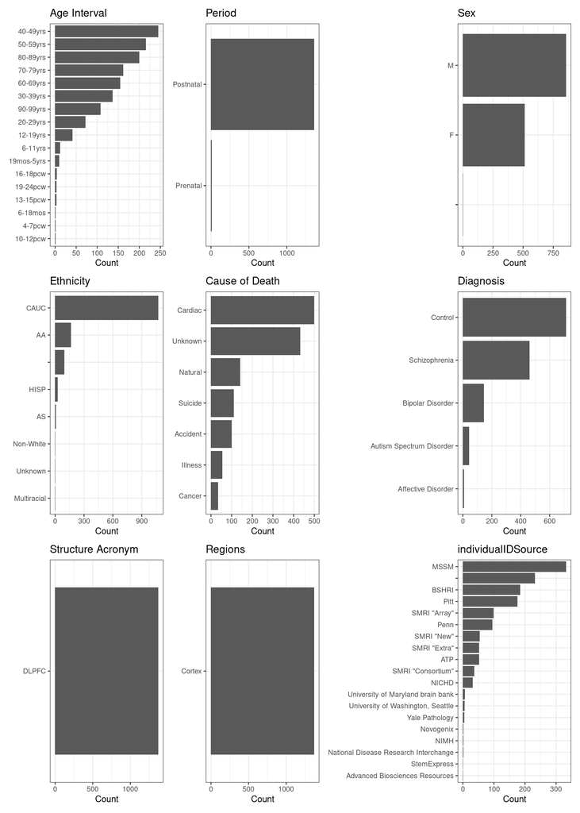

Barplot showing counts of categorial metadata for PsychENCODE

```r
wrap_plots(res$categorical_plots, ncol = 3)
```

- Numerical values

```r
res$numeric_summary %>% DT::datatable(caption = "Summary statistics for the selected numerical PsychENCODE metadata, including number of samples per category, range of numerical distributions and number of samples with NAs.")
```

|  | column | n | n_na | min | q1 | median | mean | q3 | max | sd |
| --- | --- | --- | --- | --- | --- | --- | --- | --- | --- | --- |
| 1 | Age (Numeric) | 1371 | 0 | -0.651923076923077 | 42.265359 | 57 | 57.57190833411884 | 78 | 91 | 22.4708235585764 |
| 2 | Brain Weight | 1159 | 212 | 739 | 1160 | 1299 | 1294.868852459016 | 1430 | 1980 | 186.0800291775001 |
| 3 | Height | 692 | 679 | 48 | 65 | 68 | 67.50867052023122 | 70 | 78 | 4.203049677866595 |
| 4 | Weight | 746 | 625 | 73 | 135.25 | 172 | 178.5723860589812 | 210 | 419 | 56.59058891039441 |
| 5 | Adult Ex1 (PsychENCODE) | 1371 | 0 | 0 | 0.1212351461185325 | 0.141962170967944 | 0.1428283337125485 | 0.1627547264821095 | 0.31102410054558 | 0.03747931454323022 |
| 6 | Adult Ex2 (PsychENCODE) | 1371 | 0 | 0 | 0 | 0 | 6.296906652767436e-05 | 0 | 0.0251295313357143 | 0.0009583909839484833 |
| 7 | Adult Ex3 (PsychENCODE) | 1371 | 0 | 0 | 0 | 0.0252879201042425 | 0.03086641802399432 | 0.0520984835836526 | 0.156759282768855 | 0.03036729460035741 |
| 8 | Adult Ex4 (PsychENCODE) | 1371 | 0 | 0 | 0.0284032107107468 | 0.0462354713225784 | 0.04734124301485381 | 0.0670757186254142 | 0.135173627025053 | 0.02626529583105826 |
| 9 | Adult Ex5 (PsychENCODE) | 1371 | 0 | 0 | 0.03850019587855436 | 0.0700514258534514 | 0.06903805218447849 | 0.09809631096797156 | 0.180425845238469 | 0.04026724631967397 |
| 10 | Adult Ex6 (PsychENCODE) | 1371 | 0 | 0 | 0 | 0 | 0.0009307088567217591 | 0 | 0.174396583384947 | 0.01027153164655771 |

[output cut: 18 more lines]

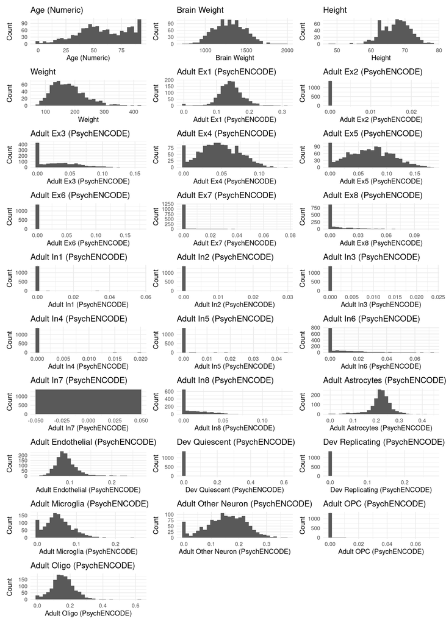

Histogram showing distribution of numerical metadata.

```r
wrap_plots(res$numeric_plots, ncol = 3)
```

### Export data

```r
#write.csv(exp, file = file.path(paths$bulk$formatted$psychencode, "PsychEncode-exp.csv"))
#write.csv(md, file = file.path(paths$bulk$formatted$psychencode,"PsychEncode-metadata.csv"), row.names = FALSE)
 write.csv(md, file = file.path(here::here("output/metadata"), "PsychEncode-metadata.csv"), row.names = FALSE)
 write.csv(pe.order, file = file.path(here::here("data/annotations"), "PE-annot-final.csv"))
```

# Single nucleus RNA-seq data pre-process